# pulmonic_stenosis_informative_priors

Alex German

2026-08-31

# Load packages

```r
library(tidyverse)
library(pammtools)
library(splines2)
library(posterior)
library(ggplot2)
library(rethinking)
library(survminer)
library(survival)
library(cowplot)
library(rstanarm)
library(bayestestR)
library(brms)
library(tidybayes)
library(bayesplot)
```

# I. Type

Coded as… • A • B • Intermediate

## 1. Previous studies for stenosis type

Locatelli et al., JSAP 2013 • Valve morphology type B (thickened, hypoplastic annulus) → In whole population HR 3.33 (95%-CI 1·689-6·579) Intermediate type. No difference cf type A, though exact figures not reported. 172 dogs

Chetboul et al. 2018 Did not assess type

Bonvin (Utrecht Thesis, 2019) • Valve morphology type B: poor outcome in PBV group (HR 7.026; 95%-CI 1.268-38.928) Intermediate type. No difference cf type A, though exact figures not reported. 112 dogs

Use Bayes theorum to combine the evidence from these two studies to inform the prior for the effect of type B and AB on survival in our model Use brm with estimate | se(error) to combine the evidence from the two studies, which allows us to use the point estimate and standard error (derived from the confidence intervals) from each study

## 1. Determine location and scale (sem) for type B

### a. Using Locatelli

```r
median_exp_l_type <- log(3.33)
lower_exp_l_type <- log(1.689)
upper_exp_l_type <- log(6.579)
range_l_type <- upper_exp_l_type - lower_exp_l_type
scale_l_type <- range_l_type / 3.96
prior_exp_l_type <- matrix(c(median_exp_l_type,
                    range_l_type,
                    scale_l_type)
)
colnames(prior_exp_l_type) <- "locatelli"
rownames(prior_exp_l_type) <- c("location", "range", "scale")
prior_exp_l_type
```

```
##          locatelli
## location 1.2029723
## range    1.3597461
## scale    0.3433702
```

### b. Using Chetboul

```r
median_exp_c_type <- NA
lower_exp_c_type <- NA
upper_exp_c_type <- NA
range_c_type <- upper_exp_c_type - lower_exp_c_type
scale_c_type <- range_c_type / 4
prior_exp_c_type <- matrix(c(median_exp_c_type,
                    range_c_type,
                    scale_c_type)
)
colnames(prior_exp_c_type) <- "chetboul"
rownames(prior_exp_c_type) <- c("location", "range", "scale")
prior_exp_c_type
```

```
##          chetboul
## location       NA
## range          NA
## scale          NA
```

### c. Using Bonvin

```r
median_exp_b_type <- log(7.026)
lower_exp_b_type <- log(1.268)
upper_exp_b_type <- log(38.928)
range_b_type <- upper_exp_b_type - lower_exp_b_type
scale_b_type <- range_b_type / 3.96
prior_exp_b_type <- matrix(c(median_exp_b_type,
                    range_b_type,
                    scale_b_type)
)
colnames(prior_exp_b_type) <- "bonvin"
rownames(prior_exp_b_type) <- c("location", "range", "scale")
prior_exp_b_type
```

```
##             bonvin
## location 1.9496176
## range    3.4242729
## scale    0.8647154
```

## 2. Set very weak neutral regularising prior

very small datasets (1-3 values) , so prior could impact on the posterior significantly. Therefore, set scale to 10, make prior virtually flat but not uniform.

```r
prior_type <- set_prior("normal(0, 10)", class = "b", coef = "Intercept")
```

## 3. Create a dataframe for the likelihood based on the Locatelli and Bonvin studies

```r
df_type <- data.frame(
  estimate = c(median_exp_l_type, median_exp_c_type, median_exp_b_type), # Observed scale for all studies
  error = c(scale_l_type, scale_c_type, scale_b_type)      # Observed SD (Standard Error) for all studies
)
```

## 4. Run model

```r
set.seed(999)
model_type <- brm(estimate | se(error) ~ 0 + Intercept,
                   family = gaussian(),
                   data = df_type,
                   prior = prior_type,
                   control=list(adapt_delta=0.98),
                   iter = 2000, warmup = 1000,
                   save_pars = save_pars(all =TRUE),
                   sample_prior = TRUE)
```

```
## Trying to compile a simple C file
```

[output not shown]

## View MCMC trace plots

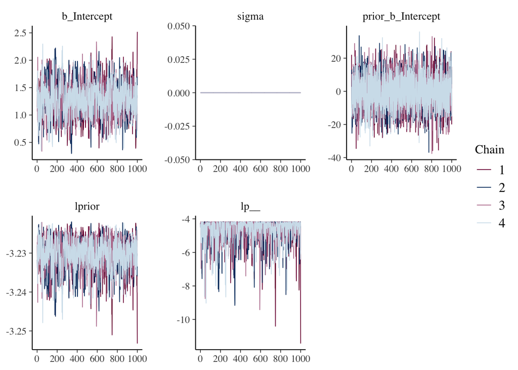

```r
color_scheme_set("mix-blue-pink")
posterior_model_type <- as.array(model_type)
mcmc_trace(posterior_model_type)
```

### b. Trace rank plot

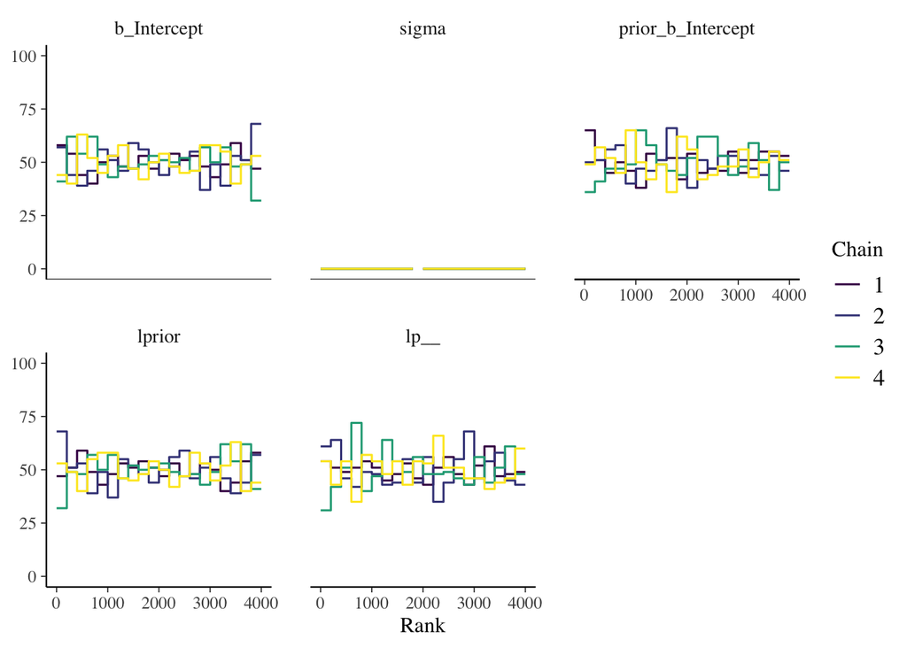

```r
color_scheme_set("viridis")
mcmc_rank_overlay(posterior_model_type) +
  ylim(0, 100)
```

## 5. get summary of model

```r
summary(model_type)
```

```
##  Family: gaussian
##   Links: mu = identity
## Formula: estimate | se(error) ~ 0 + Intercept
##    Data: df_type (Number of observations: 2)
##   Draws: 4 chains, each with iter = 2000; warmup = 1000; thin = 1;
##          total post-warmup draws = 4000
##
## Regression Coefficients:
##           Estimate Est.Error l-95% CI u-95% CI Rhat Bulk_ESS Tail_ESS
## Intercept     1.29      0.32     0.65     1.93 1.00     1099      901
##
## Further Distributional Parameters:
##       Estimate Est.Error l-95% CI u-95% CI Rhat Bulk_ESS Tail_ESS
## sigma     0.00      0.00     0.00     0.00   NA       NA       NA
##
## Draws were sampled using sampling(NUTS). For each parameter, Bulk_ESS
## and Tail_ESS are effective sample size measures, and Rhat is the potential
## scale reduction factor on split chains (at convergence, Rhat = 1).
```

## 6. Get location (median estimate) and scale (SD)

```r
draws <- as.matrix(model_type)
location_type <- mean(draws[,1]) # draws for type_b
scale_type <- sd(draws[,1])
location_type
```

```
## [1] 1.292032
```

```r
scale_type
```

```
## [1] 0.3219278
```

## 7. Compare prior and posterior

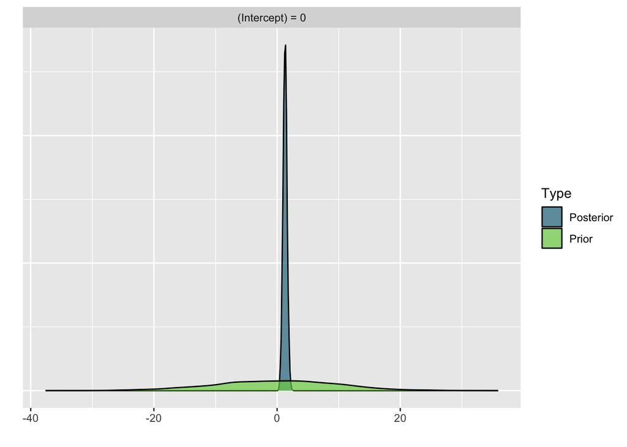

```r
plot(hypothesis(model_type, "Intercept = 0"))
```

## 8. Decision…

**Set an informative prior…**

student_t(df = 3, location = 1.292032, scale = 0.3219278)

### a. Prior for beta of type

```r
prior_beta_type <- student_t(df = 3, location = location_type, scale = scale_type, autoscale = FALSE)
```

### b. Suggested scales assuming strong, moderate and weak priors.

Given such a small scale, best to adjust the strong prior is based on the combined estimate from the literature, whilst moderate and weak priors are then scaled up from the strong prior. These latter priors ensure that the data are not overwhelmed by the prior, but still allow for some regularisation to improve model convergence and reduce overfitting. Therefore, strong prior should be 1x the combine scale, then increase this by 2x for moderate and 4x for weak.

```r
strong_scale <- scale_type
moderate_scale <- strong_scale * 2
weak_scale <- strong_scale * 4

prior_scale_type <- matrix(c(strong_scale,
                        moderate_scale,
                        weak_scale)
)
colnames(prior_scale_type) <- "suggested scale"
rownames(prior_scale_type) <- c("strong", "moderate", "weak")
prior_scale_type
```

```
##          suggested scale
## strong         0.3219278
## moderate       0.6438556
## weak           1.2877111
```

### c. Priors bin

```r
priors_bin_type <- list(
  weak = student_t(df = 3, location = location_type, scale = weak_scale, autoscale = TRUE),
  moderate = student_t(df = 3, location = location_type, scale = moderate_scale, autoscale = TRUE),
  strong = student_t(df = 3, location = location_type, scale = strong_scale, autoscale = TRUE)
)
```

## 9. Plot comparison of study distribution vs. posterior

### a. Generate posterior for plotting

```r
# 1. Extract the Posterior and Prior draws
draws <- model_type %>%
  spread_draws(b_Intercept) %>%
  dplyr::rename(Posterior = b_Intercept) %>%
  pivot_longer(cols = Posterior, names_to = "Source", values_to = "Value")

# 2. Define the Likelihood parameters (from Locatelli study)
locatelli_med <- median_exp_l_type
locatelli_se   <- scale_l_type

# 3. Define the Likelihood parameters (from Chetboul study)
chetboul_med <- median_exp_c_type
chetboul_se   <- scale_c_type

# 4. Define the Likelihood parameters (from Bonvin study)
bonvin_med <- median_exp_b_type
bonvin_se   <- scale_b_type
```

### b. Create the density plot

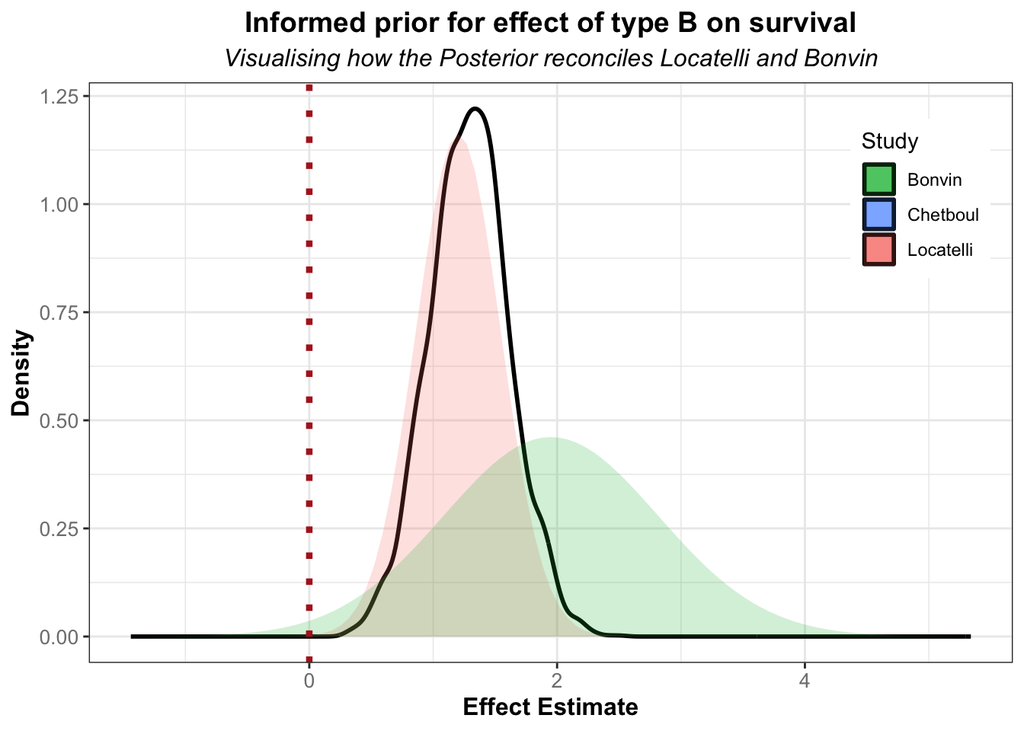

```r
# Create the Plot
ggplot() +
  # LAYER 1: Posterior (from your HMC draws)
  geom_density(
    data = draws,
    aes(x = Value),
    alpha = 0.7,
    color = "black",
    linewidth = 1
  ) +


  # LAYER 2: Distribution from Locatelli (Generated mathematically to match the others)
  # We use stat_function with 'geom = "area"' to create a shaded shape
  stat_function(
    data = data.frame(Value = c(locatelli_med - 3.92 * locatelli_se, locatelli_med + 3.92 * locatelli_se)),
    aes(x = Value, fill = "Locatelli"),
    fun = dnorm,
    args = list(mean = locatelli_med , sd = locatelli_se),
    geom = "area",
    alpha = 0.2,
    inherit.aes = FALSE
  ) +

   # LAYER 3: Distribution from Chetboul (Generated mathematically to match the others)
  # We use stat_function with 'geom = "area"' to create a shaded shape
  stat_function(
    data = data.frame(Value = c(chetboul_med - 3.92 * chetboul_se, chetboul_med + 3.92 * chetboul_se)),
    aes(x = Value, fill = "Chetboul"),
    fun = dnorm,
    args = list(mean = chetboul_med, sd = chetboul_se),
    geom = "area",
    alpha = 0.2,
    inherit.aes = FALSE
  ) +

    # LAYER 4: Distribution from Bonvin (Generated mathematically to match the others)
  # We use stat_function with 'geom = "area"' to create a shaded shape
  stat_function(
    data = data.frame(Value = c(bonvin_med - 3.92 * bonvin_se, bonvin_med + 3.92 * bonvin_se)),
    aes(x = Value, fill = "Bonvin"),
    fun = dnorm,
    args = list(mean = bonvin_med, sd = bonvin_se),
    geom = "area",
    alpha = 0.2,
    inherit.aes = FALSE
  ) +


  # Styling the Colors
  scale_fill_manual(
    values = c(
      "Locatelli" = "#F8766D",
      "Chetboul" = "#619CFF",
      "Bonvin" = "#00BA38"
    )
  ) +
  labs(
    title = "Informed prior for effect of type B on survival",
    subtitle = "Visualising how the Posterior reconciles Locatelli and Bonvin",
    x = "Effect Estimate",
    y = "Density",
    fill = "Component"
  ) +
  theme_bw() +
  theme(legend.position = c(0.9, 0.8)) +
  labs(fill = "Study") +

           theme(axis.title.y = element_text(size=12, face="bold"),
               axis.title.x = element_text(size=12, face="bold"),
               plot.title = element_text(hjust = 0.5, size=14, face="bold"),
               plot.subtitle = element_text(size = 12, hjust = 0.5, face = "italic"),
               axis.text.x = element_text(color = "grey50", size = 10),
               axis.text.y = element_text(color = "grey50",size = 10)) +
  geom_vline(xintercept = 0, linetype="dotted",
                color = "firebrick", linewidth = 1.5)
```

# II. Age (in months)

Coded as… • Standardised • SD = 19.4778645 • mean 18 months, median 11 months, range 2 to 132 months

## Previous studies for age

Chetboul et al • Age (years) — HR = 2.3 per 1-year increase, p = 0.02… • (Older age at diagnosis associated with shorter time to cardiac death). 2.3 (per 1 year increase; 95% CI¼ 1.2-4.4; p= 0.02)

Scansen • Younger age at diagnosis (discussed as suggesting more severe disease in some contexts) — presented as a factor clinicians consider for earlier intervention (not shown as a quantified HR in the review).

```r
# mean
1/3.96
```

```
## [1] 0.2525253
```

```r
# lower 95%-CI
1/8.307
```

```
## [1] 0.1203804
```

```r
# upper 95%-CI
1/1.837
```

```
## [1] 0.5443658
```

Bonvin Found a linear increase in HR per month of age as 1.020 (1.001-1.039)

## Determine coefficient for age

### a. Using Locatelli

NB Assume <12 months is a 1 SD change from location

```r
median_exp_l_age <- log(0.2525253)
lower_exp_l_age <- log(0.1203804)
upper_exp_l_age <- log(0.5443658)
range_l_age <- upper_exp_l_age - lower_exp_l_age
scale_l_age <- range_l_age / 3.96
prior_exp_l_age <- matrix(c(median_exp_l_age,
                    range_l_age,
                    scale_l_age)
)
colnames(prior_exp_l_age) <- "locatelli"
rownames(prior_exp_l_age) <- c("location", "range", "scale")
prior_exp_l_age
```

```
##           locatelli
## location -1.3762438
## range     1.5089647
## scale     0.3810517
```

### b. Using Chetboul

```r
median_exp_c_age <- log(2.3 ^ (19/12))
lower_exp_c_age <- log(1.2 ^ (19/12))
upper_exp_c_age <- log(4.4 ^ (19/12))
range_c_age <- upper_exp_c_age - lower_exp_c_age
scale_c_age <- range_c_age / 3.96
prior_exp_c_age <- matrix(c(median_exp_c_age,
                    range_c_age,
                    scale_c_age)
)
colnames(prior_exp_c_age) <- "chetboul"
rownames(prior_exp_c_age) <- c("location", "range", "scale")
prior_exp_c_age
```

```
##           chetboul
## location 1.3187728
## range    2.0571981
## scale    0.5194945
```

### c. Using Bonvin

HRs presented per month of age Need to standardise to 1 SD of current study which is 19 months Therefore, multiply by 19

```r
median_exp_b_age <- log(1.020 ^ 19)
lower_exp_b_age <- log(1.001 ^ 19)
upper_exp_b_age <- log(1.039 ^ 19)
range_b_age <- upper_exp_b_age - lower_exp_b_age
scale_b_age <- range_b_age / 3.96
prior_exp_b_age <- matrix(c(median_exp_b_age,
                    range_b_age,
                    scale_b_age)
)
colnames(prior_exp_b_age) <- "bonvin"
rownames(prior_exp_b_age) <- c("location", "range", "scale")
prior_exp_b_age
```

```
##             bonvin
## location 0.3762499
## range    0.7079250
## scale    0.1787689
```

## 2. Set very weak neutral regularising prior

very small datasets (1-3 values) , so prior could impact on the posterior significantly. Therefore, set scale to 10, make prior virtually flat but not uniform.

```r
prior_age <- set_prior("normal(0, 10)", class = "b", coef = "Intercept")
```

```r
df_age <- data.frame(
  estimate = c(median_exp_l_age, median_exp_c_age, median_exp_b_age), # Observed scales for all studies
  error = c(scale_l_age, scale_c_age, scale_b_age)      # Observed SD (Standard Error) for all studies
  )
```

## 4. Run model

```r
set.seed(999)
model_age <- brm(estimate | se(error) ~ 0 + Intercept,
                   family = gaussian(),
                   data = df_age,
                   prior = prior_age,
                   control=list(adapt_delta=0.98),
                   iter = 2000, warmup = 1000,
                   save_pars = save_pars(all =TRUE),
                   sample_prior = TRUE)
```

```
## Trying to compile a simple C file
```

[output not shown]

## View MCMC trace plots

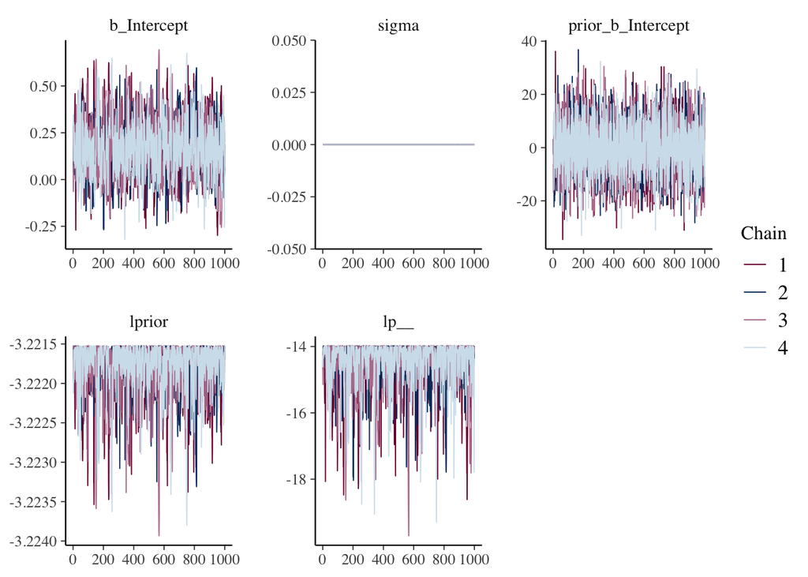

```r
color_scheme_set("mix-blue-pink")
posterior_model_age <- as.array(model_age)
mcmc_trace(posterior_model_age)
```

### b. Trace rank plot

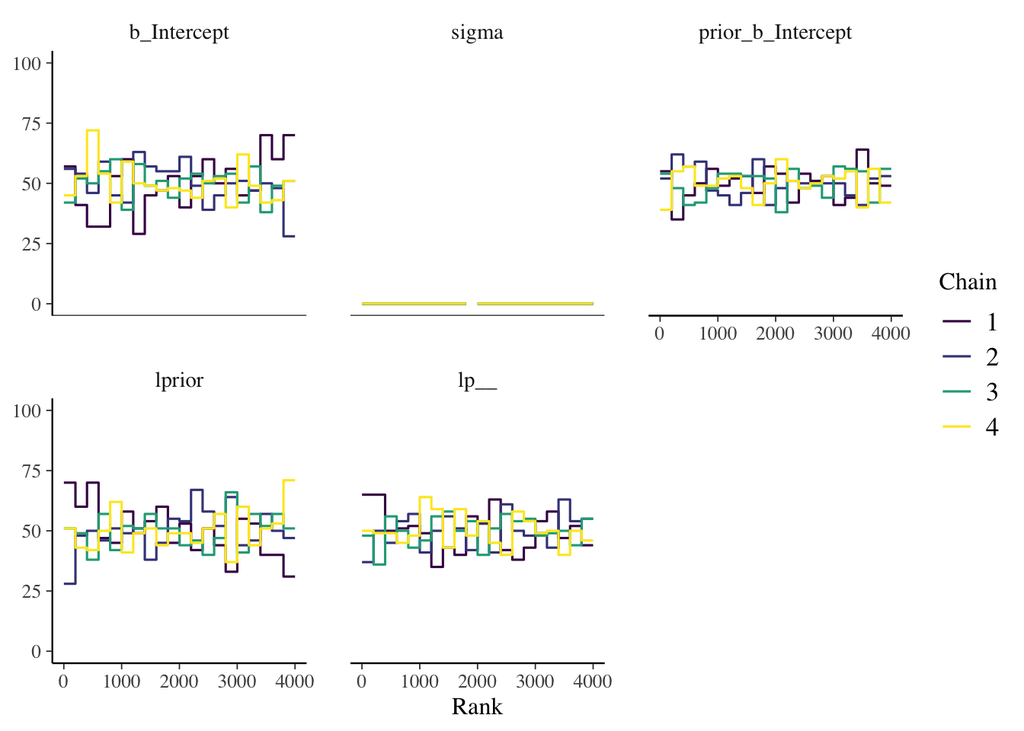

```r
color_scheme_set("viridis")
mcmc_rank_overlay(posterior_model_age) +
  ylim(0, 100)
```

## 5. get summary of model

```r
summary(model_age)
```

```
##  Family: gaussian
##   Links: mu = identity
## Formula: estimate | se(error) ~ 0 + Intercept
##    Data: df_age (Number of observations: 3)
##   Draws: 4 chains, each with iter = 2000; warmup = 1000; thin = 1;
##          total post-warmup draws = 4000
##
## Regression Coefficients:
##           Estimate Est.Error l-95% CI u-95% CI Rhat Bulk_ESS Tail_ESS
## Intercept     0.17      0.16    -0.13     0.50 1.00     1002      942
##
## Further Distributional Parameters:
##       Estimate Est.Error l-95% CI u-95% CI Rhat Bulk_ESS Tail_ESS
## sigma     0.00      0.00     0.00     0.00   NA       NA       NA
##
## Draws were sampled using sampling(NUTS). For each parameter, Bulk_ESS
## and Tail_ESS are effective sample size measures, and Rhat is the potential
## scale reduction factor on split chains (at convergence, Rhat = 1).
```

## 6. Get location (median estimate) and scale (SD)

```r
draws <- as.matrix(model_age)
location_age <- mean(draws[,1]) # draws for type
scale_age <- sd(draws[,1])
location_age
```

```
## [1] 0.1731489
```

```r
scale_age
```

```
## [1] 0.1596095
```

## 7. Compare prior and posterior

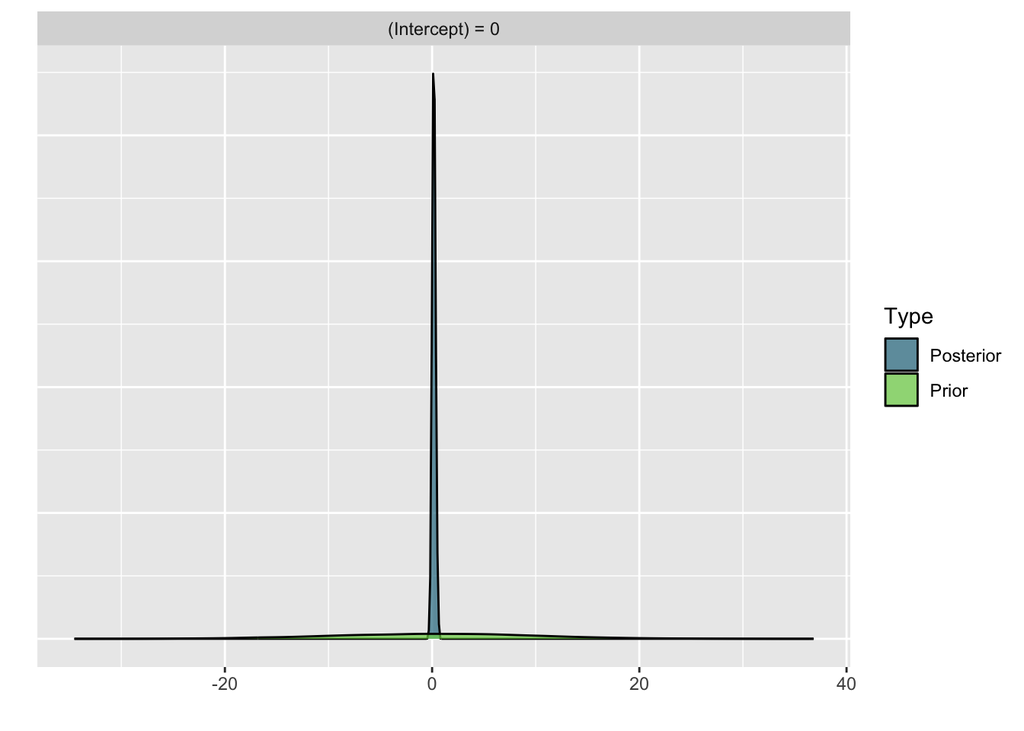

```r
plot(hypothesis(model_age, "Intercept = 0"))
```

## 8. Decision…

**Set an informative prior…**

student_t(df = 3, location = 0.1731489, scale = 0.1596095)

### a. Prior for beta of age

```r
prior_beta_age <- student_t(df = 3, location = location_age, scale = scale_age, autoscale = TRUE)
```

### b. Suggested scales assuming strong, moderate and weak priors.

```r
strong_scale <- scale_age
moderate_scale <- strong_scale * 2
weak_scale <- strong_scale * 4

prior_scale_age <- matrix(c(strong_scale,
                        moderate_scale,
                        weak_scale)
)
colnames(prior_scale_age) <- "suggested scale"
rownames(prior_scale_age) <- c("strong", "moderate", "weak")
prior_scale_age
```

```
##          suggested scale
## strong         0.1596095
## moderate       0.3192190
## weak           0.6384379
```

### c. Priors bin

```r
priors_bin_age <- list(
  weak = student_t(df = 3, location = location_age, scale = weak_scale, autoscale = TRUE),
  moderate = student_t(df = 3, location = location_age, scale = moderate_scale, autoscale = TRUE),
  strong = student_t(df = 3, location = location_age, scale = strong_scale, autoscale = TRUE)
)
```

## 9. Plot comparison of study distribution vs. posterior

### a. Generate posterior for plotting

```r
# 1. Extract the Posterior and Prior draws
draws <- model_age %>%
  spread_draws(b_Intercept) %>%
  dplyr::rename(Posterior = b_Intercept) %>%
  pivot_longer(cols = Posterior, names_to = "Source", values_to = "Value")

# 2. Define the Likelihood parameters (from Locatelli study)
locatelli_med <- median_exp_l_age
locatelli_se   <- scale_l_age

# 3. Define the Likelihood parameters (from Chetboul study)
chetboul_med <- median_exp_c_age
chetboul_se   <- scale_c_age

# 4. Define the Likelihood parameters (from Bonvin study)
bonvin_med <- median_exp_b_age
bonvin_se   <- scale_b_age
```

### b. Create the density plot

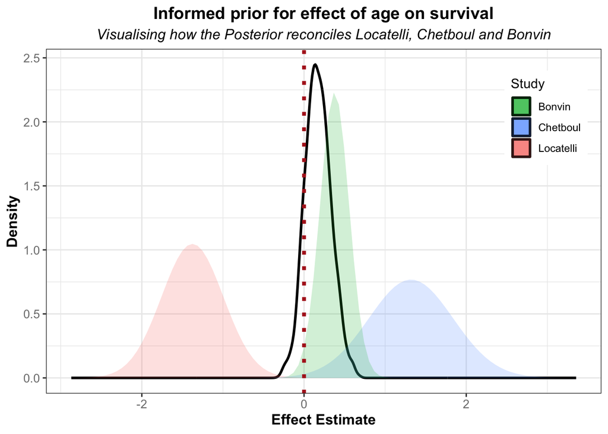

```r
# Create the Plot
ggplot() +
  # LAYER 1: Posterior (from your HMC draws)
  geom_density(
    data = draws,
    aes(x = Value),
    alpha = 0.7,
    color = "black",
    linewidth = 1
  ) +


  # LAYER 2: Distribution from Locatelli (Generated mathematically to match the others)
  # We use stat_function with 'geom = "area"' to create a shaded shape
  stat_function(
    data = data.frame(Value = c(locatelli_med - 3.92 * locatelli_se, locatelli_med + 3.92 * locatelli_se)),
    aes(x = Value, fill = "Locatelli"),
    fun = dnorm,
    args = list(mean = locatelli_med , sd = locatelli_se),
    geom = "area",
    alpha = 0.2,
    inherit.aes = FALSE
  ) +

   # LAYER 3: Distribution from Chetboul (Generated mathematically to match the others)
  # We use stat_function with 'geom = "area"' to create a shaded shape
  stat_function(
    data = data.frame(Value = c(chetboul_med - 3.92 * chetboul_se, chetboul_med + 3.92 * chetboul_se)),
    aes(x = Value, fill = "Chetboul"),
    fun = dnorm,
    args = list(mean = chetboul_med, sd = chetboul_se),
    geom = "area",
    alpha = 0.2,
    inherit.aes = FALSE
  ) +

    # LAYER 4: Distribution from Bonvin (Generated mathematically to match the others)
  # We use stat_function with 'geom = "area"' to create a shaded shape
  stat_function(
    data = data.frame(Value = c(bonvin_med - 3.92 * bonvin_se, bonvin_med + 3.92 * bonvin_se)),
    aes(x = Value, fill = "Bonvin"),
    fun = dnorm,
    args = list(mean = bonvin_med, sd = bonvin_se),
    geom = "area",
    alpha = 0.2,
    inherit.aes = FALSE
  ) +


  # Styling the Colors
  scale_fill_manual(
    values = c(
      "Locatelli" = "#F8766D",
      "Chetboul" = "#619CFF",
      "Bonvin" = "#00BA38"
    )
  ) +
  labs(
    title = "Informed prior for effect of age on survival",
    subtitle = "Visualising how the Posterior reconciles Locatelli, Chetboul and Bonvin",
    x = "Effect Estimate",
    y = "Density",
    fill = "Component"
  ) +
  theme_bw() +
  theme(legend.position = c(0.9, 0.8)) +
  labs(fill = "Study") +

           theme(axis.title.y = element_text(size=12, face="bold"),
               axis.title.x = element_text(size=12, face="bold"),
               plot.title = element_text(hjust = 0.5, size=14, face="bold"),
               plot.subtitle = element_text(size = 12, hjust = 0.5, face = "italic"),
               axis.text.x = element_text(color = "grey50", size = 10),
               axis.text.y = element_text(color = "grey50",size = 10)) +
  geom_vline(xintercept = 0, linetype="dotted",
                color = "firebrick", linewidth = 1.5)
```

# III. Surgery

Coded as… • 0 (no) • 1 (yes)

## 1, Previous studies for surgery

Locatelli et al., JSAP 2013 • Treatment effect: PBV improved survival in severe PS; asymptomatic moderate PS also had better outcomes. balloon valvuloplasty (HR 0·47, P=0·047) no BVP in severe PS (HR 2·11, 95%CI 1·011-4·396) Inverse are HRs for BVP (nb severe PS)…

```r
1/2.11
```

```
## [1] 0.4739336
```

```r
1/1.011
```

```
## [1] 0.9891197
```

```r
1/4.396
```

```
## [1] 0.2274795
```

Bonvin (Utrecht Thesis, 2019) • PBV treatment: protective factor, significantly prolongs survival in severe PS Severe and moderate BBP… HR 0.339 (0.135-0.854)

## Coefficient for surgery

### a. Using Locatelli

```r
median_exp_l_sx <- log(0.4739336)
lower_exp_l_sx <- log(0.2274795)
upper_exp_l_sx <- log(0.9891197)
range_l_sx <- upper_exp_l_sx - lower_exp_l_sx
scale_l_sx <- range_l_sx / 3.92
prior_exp_l_sx <- matrix(c(median_exp_l_sx,
                    range_l_sx,
                    scale_l_sx)
)
colnames(prior_exp_l_sx) <- "locatelli"
rownames(prior_exp_l_sx) <- c("location", "range", "scale")
prior_exp_l_sx
```

```
##           locatelli
## location -0.7466881
## range     1.4697552
## scale     0.3749376
```

### b. Using Chetboul

```r
median_exp_c_sx <- NA
lower_exp_c_sx <- NA
upper_exp_c_sx <- NA
range_c_sx <- upper_exp_c_sx - lower_exp_c_sx
scale_c_sx <- range_c_sx / 4
prior_exp_c_sx <- matrix(c(median_exp_c_sx,
                    range_c_sx,
                    scale_c_sx)
)
colnames(prior_exp_c_sx) <- "chetboul"
rownames(prior_exp_c_sx) <- c("location", "range", "scale")
prior_exp_c_sx
```

```
##          chetboul
## location       NA
## range          NA
## scale          NA
```

### b. Using Bonvin

```r
median_exp_b_sx <- log(0.339)
lower_exp_b_sx <- log(0.135)
upper_exp_b_sx <- log(0.854)
range_b_sx <- upper_exp_b_sx - lower_exp_b_sx
scale_b_sx <- range_b_sx / 3.92
prior_exp_b_sx <- matrix(c(median_exp_b_sx,
                    range_b_sx,
                    scale_b_sx)
)
colnames(prior_exp_b_sx) <- "bonvin"
rownames(prior_exp_b_sx) <- c("location", "range", "scale")
prior_exp_b_sx
```

```
##              bonvin
## location -1.0817552
## range     1.8446564
## scale     0.4705756
```

## 2. Set very weak neutral regularising prior

very small datasets (1-3 values) , so prior could impact on the posterior significantly. Therefore, set scale to 10, make prior virtually flat but not uniform.

```r
prior_sx <- set_prior("normal(0, 10)", class = "b", coef = "Intercept")
```

```r
df_sx <- data.frame(
  estimate = c(median_exp_l_sx, median_exp_c_sx, median_exp_b_sx), # Observed scales for all studies
  error = c(scale_l_sx, scale_c_sx, scale_b_sx)      # Observed SD (Standard Error) for all studies
)
```

## 4. Run model

```r
set.seed(999)
model_sx <- brm(estimate | se(error) ~ 0 + Intercept,
                   family = gaussian(),
                   data = df_sx,
                   prior = prior_sx,
                   control=list(adapt_delta=0.98),
                   iter = 2000, warmup = 1000,
                   save_pars = save_pars(all =TRUE),
                   sample_prior = TRUE)
```

```
## Trying to compile a simple C file
```

[output not shown]

## View MCMC trace plots

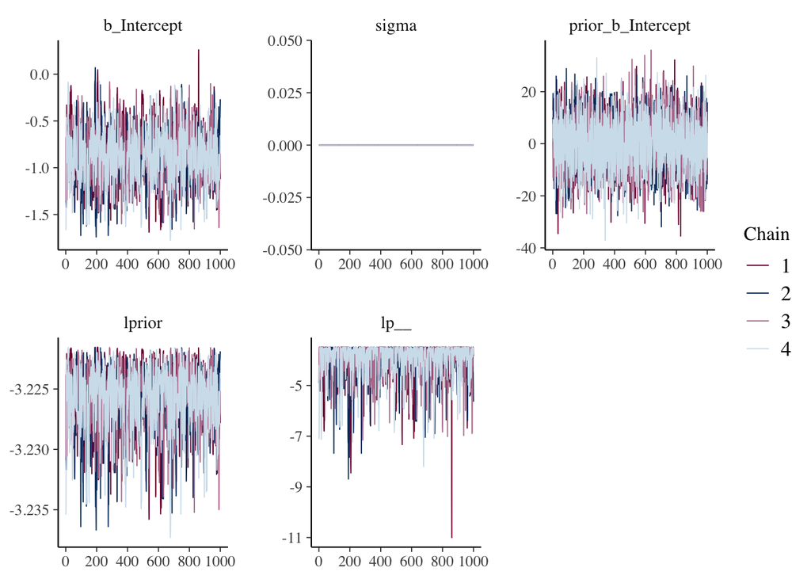

```r
color_scheme_set("mix-blue-pink")
posterior_model_sx <- as.array(model_sx)
mcmc_trace(posterior_model_sx)
```

### b. Trace rank plot

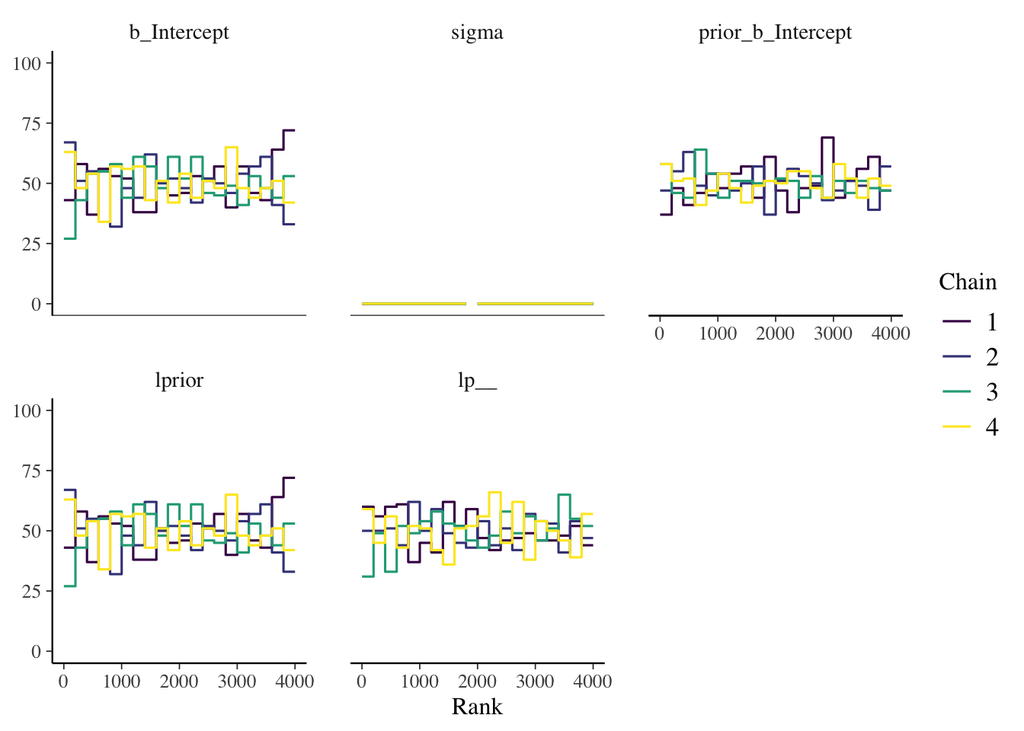

```r
color_scheme_set("viridis")
mcmc_rank_overlay(posterior_model_sx) +
  ylim(0, 100)
```

## 5. get summary of model

```r
summary(model_sx)
```

```
##  Family: gaussian
##   Links: mu = identity
## Formula: estimate | se(error) ~ 0 + Intercept
##    Data: df_sx (Number of observations: 2)
##   Draws: 4 chains, each with iter = 2000; warmup = 1000; thin = 1;
##          total post-warmup draws = 4000
##
## Regression Coefficients:
##           Estimate Est.Error l-95% CI u-95% CI Rhat Bulk_ESS Tail_ESS
## Intercept    -0.88      0.29    -1.48    -0.29 1.00     1224     1173
##
## Further Distributional Parameters:
##       Estimate Est.Error l-95% CI u-95% CI Rhat Bulk_ESS Tail_ESS
## sigma     0.00      0.00     0.00     0.00   NA       NA       NA
##
## Draws were sampled using sampling(NUTS). For each parameter, Bulk_ESS
## and Tail_ESS are effective sample size measures, and Rhat is the potential
## scale reduction factor on split chains (at convergence, Rhat = 1).
```

## 6. Get location (median estimate) and scale (SD)

```r
draws <- as.matrix(model_sx)
location_sx <- mean(draws[,1]) # draws for surgery
scale_sx <- sd(draws[,1])
location_sx
```

```
## [1] -0.879165
```

```r
scale_sx
```

```
## [1] 0.2911939
```

## 7. Compare prior and posterior

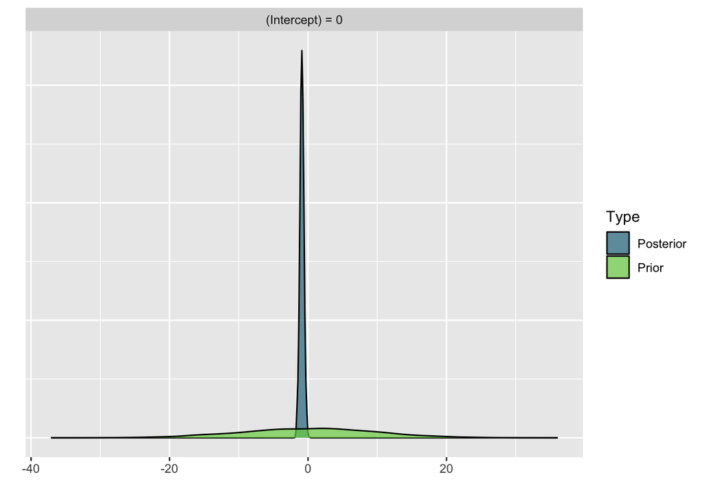

```r
plot(hypothesis(model_sx, "Intercept = 0"))
```

## 8. Decision…

**Set an informative prior…**

student_t(df = 3, location = -0.879165, scale = 0.2911939)

### a. Prior for beta of surgery

```r
prior_beta_sx <- student_t(df = 3, location = location_sx, scale = scale_sx, autoscale = TRUE)
```

### b. Suggested scales assuming strong, moderate and weak priors.

```r
strong_scale <- scale_sx
moderate_scale <- strong_scale * 2
weak_scale <- strong_scale * 4

prior_scale_sx <- matrix(c(strong_scale,
                        moderate_scale,
                        weak_scale)
)
colnames(prior_scale_sx) <- "suggested scale"
rownames(prior_scale_sx) <- c("strong", "moderate", "weak")
prior_scale_sx
```

```
##          suggested scale
## strong         0.2911939
## moderate       0.5823879
## weak           1.1647758
```

### c. Priors bin

```r
priors_bin_sx <- list(
  weak = student_t(df = 3, location = location_sx, scale = weak_scale, autoscale = TRUE),
  moderate = student_t(df = 3, location = location_sx, scale = moderate_scale, autoscale = TRUE),
  strong = student_t(df = 3, location = location_sx, scale = strong_scale, autoscale = TRUE)
)
```

## 9. Plot comparison of study distribution vs. posterior

### a. Generate posterior for plotting

```r
# 1. Extract the Posterior and Prior draws
draws <- model_sx %>%
  spread_draws(b_Intercept) %>%
  dplyr::rename(Posterior = b_Intercept) %>%
  pivot_longer(cols = Posterior, names_to = "Source", values_to = "Value")

# 2. Define the Likelihood parameters (from Locatelli study)
locatelli_med <- median_exp_l_sx
locatelli_se   <- scale_l_sx

# 3. Define the Likelihood parameters (from Chetboul study)
chetboul_med <- median_exp_c_sx
chetboul_se   <- scale_c_sx

# 4. Define the Likelihood parameters (from Bonvin study)
bonvin_med <- median_exp_b_sx
bonvin_se   <- scale_b_sx
```

### b. Create the density plot

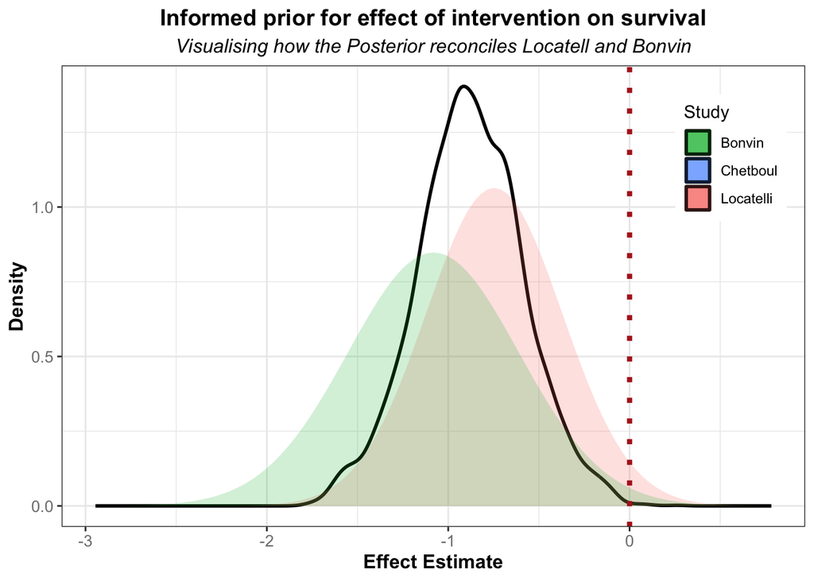

```r
# Create the Plot
ggplot() +
  # LAYER 1: Posterior (from your HMC draws)
  geom_density(
    data = draws,
    aes(x = Value),
    alpha = 0.7,
    color = "black",
    linewidth = 1
  ) +


  # LAYER 2: Distribution from Locatelli (Generated mathematically to match the others)
  # We use stat_function with 'geom = "area"' to create a shaded shape
  stat_function(
    data = data.frame(Value = c(locatelli_med - 3.96*locatelli_se, locatelli_med + 3.96*locatelli_se)),
    aes(x = Value, fill = "Locatelli"),
    fun = dnorm,
    args = list(mean = locatelli_med , sd = locatelli_se),
    geom = "area",
    alpha = 0.2,
    inherit.aes = FALSE
  ) +

   # LAYER 3: Distribution from Chetboul (Generated mathematically to match the others)
  # We use stat_function with 'geom = "area"' to create a shaded shape
  stat_function(
    data = data.frame(Value = c(chetboul_med - 3.96 * chetboul_se, chetboul_med + 3.96 * chetboul_se)),
    aes(x = Value, fill = "Chetboul"),
    fun = dnorm,
    args = list(mean = chetboul_med, sd = chetboul_se),
    geom = "area",
    alpha = 0.2,
    inherit.aes = FALSE
  ) +

    # LAYER 4: Distribution from Bonvin (Generated mathematically to match the others)
  # We use stat_function with 'geom = "area"' to create a shaded shape
  stat_function(
    data = data.frame(Value = c(bonvin_med - 3.96 * bonvin_se, bonvin_med + 3.96 * bonvin_se)),
    aes(x = Value, fill = "Bonvin"),
    fun = dnorm,
    args = list(mean = bonvin_med, sd = bonvin_se),
    geom = "area",
    alpha = 0.2,
    inherit.aes = FALSE
  ) +


  # Styling the Colors
  scale_fill_manual(
    values = c(
      "Locatelli" = "#F8766D",
      "Chetboul" = "#619CFF",
      "Bonvin" = "#00BA38"
    )
  ) +
  labs(
    title = "Informed prior for effect of intervention on survival",
    subtitle = "Visualising how the Posterior reconciles Locatell and Bonvin",
    x = "Effect Estimate",
    y = "Density",
    fill = "Component"
  ) +
  theme_bw() +
  theme(legend.position = c(0.9, 0.8)) +
  labs(fill = "Study") +

           theme(axis.title.y = element_text(size=12, face="bold"),
               axis.title.x = element_text(size=12, face="bold"),
               plot.title = element_text(hjust = 0.5, size=14, face="bold"),
               plot.subtitle = element_text(size = 12, hjust = 0.5, face = "italic"),
               axis.text.x = element_text(color = "grey50", size = 10),
               axis.text.y = element_text(color = "grey50",size = 10)) +
  geom_vline(xintercept = 0, linetype="dotted",
                color = "firebrick", linewidth = 1.5)
```

# IV. RV SYSTOLIC DYSFUNCTION (tapse)

Coded as… • Standardised • SD = 3.5080085

Scansen • Severe RV hypertrophy / RV systolic dysfunction — cited as an indicator of greater disease severity and as part of criteria favoring intervention.

## Decision…

As no clear indication of effect, set a neutral, weakly- regularising prior… ~ student_t(df = 3, location = 0, scale = 2.5)

# V. PRESSURE GRADIENT (pv_max_pg)

Coded as… • Standardised • SD = 40.9438358

## 1. Previous studies about pressure gradient

Scansen, Advances in the Treatment of Pulmonary Valve Stenosis • High transpulmonary pressure gradient higher gradients linked to worse prognosis and are used to justify intervention.

### a. Using Locatelli

• Pulmonary Doppler gradient in dogs not having balloon valvuloplasty: higher DG = worse survival Moderate PS… HR 1·02 (95%-CI 1·009-1·032) per mmHg increase in pressure gradient

1SD in the current study is 40.9438358 mmHg, so HR per 1 SD increase in pressure gradient would be..

```r
median_exp_l_pv <- log(1.02 ^ 40.9438358)
lower_exp_l_pv <- log(1.009 ^ 40.9438358)
upper_exp_l_pv <- log(1.032 ^ 40.9438358)
range_l_pv <- upper_exp_l_pv - lower_exp_l_pv
scale_l_pv <- range_l_pv / 3.92
prior_exp_l_pv <- matrix(c(median_exp_l_pv,
                    range_l_pv,
                    scale_l_pv)
)
colnames(prior_exp_l_pv) <- "locatelli"
rownames(prior_exp_l_pv) <- c("location", "range", "scale")
prior_exp_l_pv
```

```
##          locatelli
## location 0.8107955
## range    0.9228301
## scale    0.2354158
```

### b. Using Chetboul 2018

Journal of Veterinary Cardiology (2018) 20, 405e414

• Pulmonary Doppler gradient: higher DG = worse survival HR 1.2 (95%-CI 1.0-1.3) per 10 mmHg increase in pressure gradient NB per 10 mmHg so multiply by 4.09438358 and NOT 40.9438358

```r
median_exp_c_pv <- log(1.2 ^ 4.09438358)
lower_exp_c_pv <- log(1.0 ^ 4.09438358)
upper_exp_c_pv <- log(1.3 ^ 4.09438358)
range_c_pv <- upper_exp_c_pv - lower_exp_c_pv
scale_c_pv <- range_c_pv / 3.92
prior_exp_c_pv <- matrix(c(median_exp_c_pv,
                    range_c_pv,
                    scale_c_pv)
)
colnames(prior_exp_c_pv) <- "chetboul"
rownames(prior_exp_c_pv) <- c("location", "range", "scale")
prior_exp_c_pv
```

```
##           chetboul
## location 0.7464944
## range    1.0742199
## scale    0.2740357
```

### c. Using Bonvin (Utrecht Thesis, 2019)

• Pulmonary Doppler gradient: higher DG = worse survival Moderate PS… HR 1.012 (95%-CI 1.001-1.023) per mmHg increase in pressure gradient Severe PS… HR 1.013 (95%-CI 1.001-1.026) per mmHg increase in pressure gradient

1SD in the current study is 40.9438358 mmHg, so HR per 1 SD increase in pressure gradient would be..

```r
median_exp_b_pv <- log(1.0125 ^ 40.9438358)
lower_exp_b_pv <- log(1.001 ^ 40.9438358)
upper_exp_b_pv <- log(1.0245 ^ 40.9438358)
range_b_pv <- upper_exp_b_pv - lower_exp_b_pv
scale_b_pv <- range_b_pv / 3.92
prior_exp_b_pv <- matrix(c(median_exp_b_pv,
                    range_b_pv,
                    scale_b_pv)
)
colnames(prior_exp_b_pv) <- "bonvin"
rownames(prior_exp_b_pv) <- c("location", "range", "scale")
prior_exp_b_pv
```

```
##             bonvin
## location 0.5086256
## range    0.9501094
## scale    0.2423749
```

## 2. Set very weak neutral regularising prior

very small datasets (1-3 values) , so prior could impact on the posterior significantly. Therefore, set scale to 10, make prior virtually flat but not uniform.

```r
prior_pv <- set_prior("normal(0, 10)", class = "b", coef = "Intercept")
```

```r
df_pv <- data.frame(
  estimate = c(median_exp_l_pv, median_exp_c_pv, median_exp_b_pv), # Observed scales for all studies
  error = c(scale_l_pv, scale_c_pv, scale_b_pv)      # Observed SD (Standard Error) for all studies
)
```

## 4. Run model

```r
set.seed(999)
model_pv <- brm(estimate | se(error) ~ 0 + Intercept,
                   family = gaussian(),
                   data = df_pv,
                   prior = prior_pv,
                   control=list(adapt_delta=0.98),
                   iter = 2000, warmup = 1000,
                   save_pars = save_pars(all =TRUE),
                   sample_prior = TRUE)
```

```
## Trying to compile a simple C file
```

[output not shown]

## View MCMC trace plots

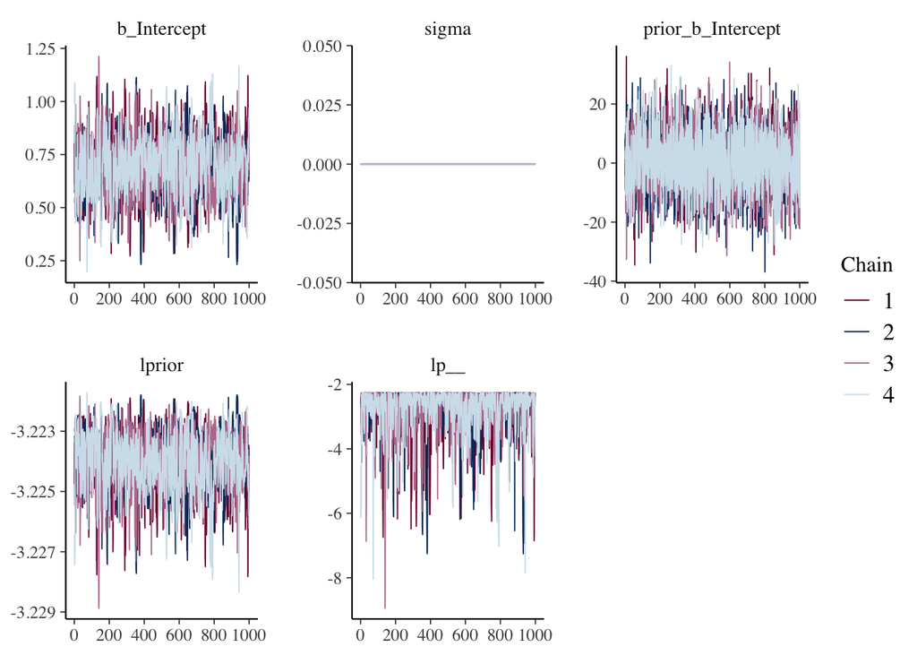

```r
color_scheme_set("mix-blue-pink")
posterior_model_pv <- as.array(model_pv)
mcmc_trace(posterior_model_pv)
```

### b. Trace rank plot

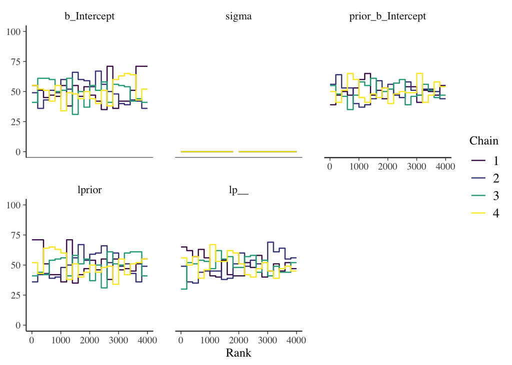

```r
color_scheme_set("viridis")
mcmc_rank_overlay(posterior_model_pv) +
  ylim(0, 100)
```

## 5. get summary of model

```r
summary(model_pv)
```

```
##  Family: gaussian
##   Links: mu = identity
## Formula: estimate | se(error) ~ 0 + Intercept
##    Data: df_pv (Number of observations: 3)
##   Draws: 4 chains, each with iter = 2000; warmup = 1000; thin = 1;
##          total post-warmup draws = 4000
##
## Regression Coefficients:
##           Estimate Est.Error l-95% CI u-95% CI Rhat Bulk_ESS Tail_ESS
## Intercept     0.69      0.15     0.40     0.97 1.00     1047     1089
##
## Further Distributional Parameters:
##       Estimate Est.Error l-95% CI u-95% CI Rhat Bulk_ESS Tail_ESS
## sigma     0.00      0.00     0.00     0.00   NA       NA       NA
##
## Draws were sampled using sampling(NUTS). For each parameter, Bulk_ESS
## and Tail_ESS are effective sample size measures, and Rhat is the potential
## scale reduction factor on split chains (at convergence, Rhat = 1).
```

## 6. Get location (median estimate) and scale (SD)

```r
draws <- as.matrix(model_pv)
location_pv <- mean(draws[,1]) # draws for type
scale_pv <- sd(draws[,1])
location_pv
```

```
## [1] 0.687753
```

```r
scale_pv
```

```
## [1] 0.1460131
```

## 7. Compare prior and posterior

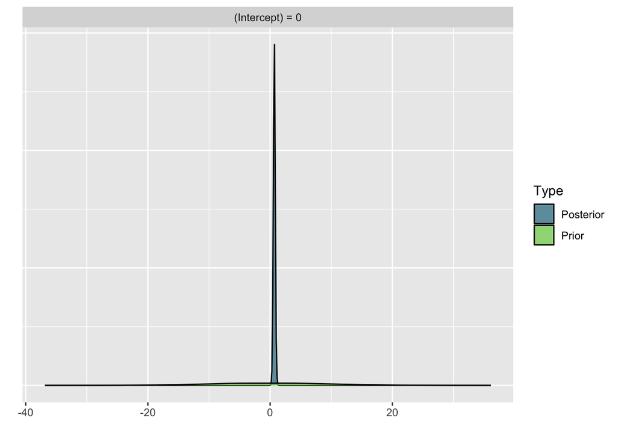

```r
plot(hypothesis(model_pv, "Intercept = 0"))
```

## 8. Decision…

**Set an informative prior…**

student_t(df = 3, location = 0.687753, scale = 0.1460131)

### a. Prior for beta of pv_max

```r
prior_beta_pv <- student_t(df = 3, location = location_pv, scale = scale_pv, autoscale = TRUE)
```

### b. Suggested scales assuming strong, moderate and weak priors.

```r
strong_scale <- scale_pv
moderate_scale <- strong_scale * 2
weak_scale <- strong_scale * 4

prior_scale_pv <- matrix(c(strong_scale,
                        moderate_scale,
                        weak_scale)
)
colnames(prior_scale_pv) <- "suggested scale"
rownames(prior_scale_pv) <- c("strong", "moderate", "weak")
prior_scale_pv
```

```
##          suggested scale
## strong         0.1460131
## moderate       0.2920263
## weak           0.5840526
```

### c. Priors bin

```r
priors_bin_pv <- list(
  weak = student_t(df = 3, location = location_pv, scale = weak_scale, autoscale = TRUE),
  moderate = student_t(df = 3, location = location_pv, scale = moderate_scale, autoscale = TRUE),
  strong = student_t(df = 3, location = location_pv, scale = strong_scale, autoscale = TRUE)
)
```

## 9. Plot comparison of study distribution vs. posterior

### a. Generate posterior for plotting

```r
# 1. Extract the Posterior and Prior draws
draws <- model_pv %>%
  spread_draws(b_Intercept) %>%
  dplyr::rename(Posterior = b_Intercept) %>%
  pivot_longer(cols = Posterior, names_to = "Source", values_to = "Value")

# 2. Define the Likelihood parameters (from Locatelli study)
locatelli_med <- median_exp_l_pv
locatelli_se   <- scale_l_pv

# 3. Define the Likelihood parameters (from Chetboul study)
chetboul_med <- median_exp_c_pv
chetboul_se   <- scale_c_pv

# 4. Define the Likelihood parameters (from Bonvin study)
bonvin_med <- median_exp_b_pv
bonvin_se   <- scale_b_pv
```

### b. Create the density plot

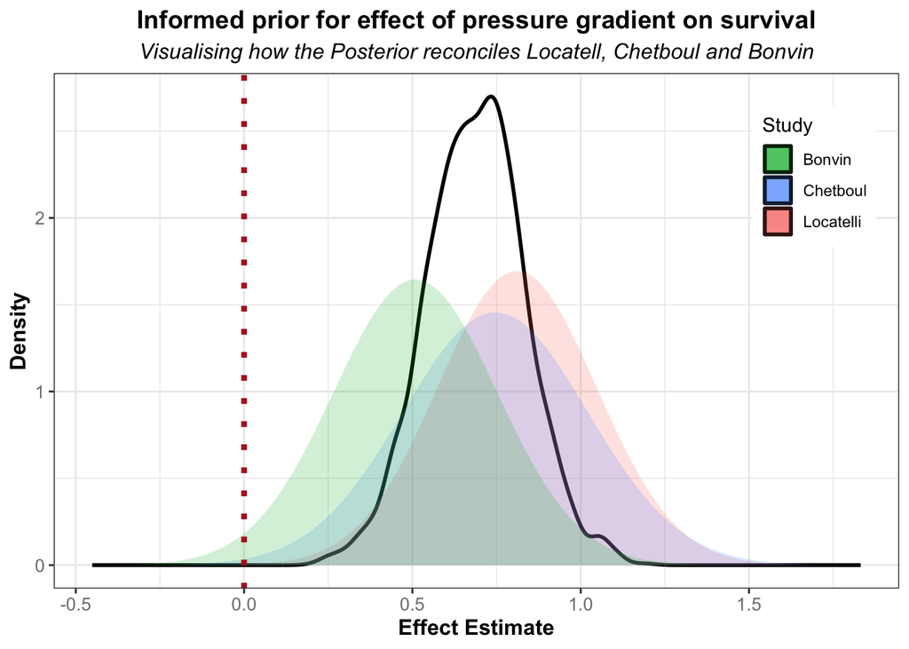

```r
# Create the Plot
ggplot() +
  # LAYER 1: Posterior (from your HMC draws)
  geom_density(
    data = draws,
    aes(x = Value),
    alpha = 0.7,
    color = "black",
    linewidth = 1
  ) +


  # LAYER 2: Distribution from Locatelli (Generated mathematically to match the others)
  # We use stat_function with 'geom = "area"' to create a shaded shape
  stat_function(
    data = data.frame(Value = c(locatelli_med - 3.96*locatelli_se, locatelli_med + 3.96*locatelli_se)),
    aes(x = Value, fill = "Locatelli"),
    fun = dnorm,
    args = list(mean = locatelli_med , sd = locatelli_se),
    geom = "area",
    alpha = 0.2,
    inherit.aes = FALSE
  ) +

   # LAYER 3: Distribution from Chetboul (Generated mathematically to match the others)
  # We use stat_function with 'geom = "area"' to create a shaded shape
  stat_function(
    data = data.frame(Value = c(chetboul_med - 3.96 * chetboul_se, chetboul_med + 3.96 * chetboul_se)),
    aes(x = Value, fill = "Chetboul"),
    fun = dnorm,
    args = list(mean = chetboul_med, sd = chetboul_se),
    geom = "area",
    alpha = 0.2,
    inherit.aes = FALSE
  ) +

    # LAYER 4: Distribution from Bonvin (Generated mathematically to match the others)
  # We use stat_function with 'geom = "area"' to create a shaded shape
  stat_function(
    data = data.frame(Value = c(bonvin_med - 3.96 * bonvin_se, bonvin_med + 3.96 * bonvin_se)),
    aes(x = Value, fill = "Bonvin"),
    fun = dnorm,
    args = list(mean = bonvin_med, sd = bonvin_se),
    geom = "area",
    alpha = 0.2,
    inherit.aes = FALSE
  ) +


  # Styling the Colors
  scale_fill_manual(
    values = c(
      "Locatelli" = "#F8766D",
      "Chetboul" = "#619CFF",
      "Bonvin" = "#00BA38"
    )
  ) +
  labs(
    title = "Informed prior for effect of pressure gradient on survival",
    subtitle = "Visualising how the Posterior reconciles Locatell, Chetboul and Bonvin",
    x = "Effect Estimate",
    y = "Density",
    fill = "Component"
  ) +
  theme_bw() +
  theme(legend.position = c(0.9, 0.8)) +
  labs(fill = "Study") +

           theme(axis.title.y = element_text(size=12, face="bold"),
               axis.title.x = element_text(size=12, face="bold"),
               plot.title = element_text(hjust = 0.5, size=14, face="bold"),
               plot.subtitle = element_text(size = 12, hjust = 0.5, face = "italic"),
               axis.text.x = element_text(color = "grey50", size = 10),
               axis.text.y = element_text(color = "grey50",size = 10)) +
  geom_vline(xintercept = 0, linetype="dotted",
                color = "firebrick", linewidth = 1.5)
```

# VI. NFD (vtiao_vtipv)

Coded as… • Standardised • SD = 0.2075744

Scansen, Advances in the Treatment of Pulmonary Valve Stenosis • Annular hypoplasia (Ao:PV > 1.2) — predicts poorer BPV success; often indicates consideration of stent implantation instead of BPV.

However, no survival analysis completed and, therefore, best to leave as a neutral prior.

## Decision…

**Set a neutral, weakly-regularising prior…**

student_t(df = 3, location = 0, scale = 2.0)

# VII. NFD (vmaxav_vmaxpv)

Coded as… • Standardised • SD = 0.2381948

Scansen, Advances in the Treatment of Pulmonary Valve Stenosis • Annular hypoplasia (Ao:PV > 1.2) — predicts poorer BPV success; often indicates consideration of stent implantation instead of BPV.

## Decision…

**Set a non-informative weekly regularising prior…**

student_t(df = 3, location = 0, scale = 2.0)

# VIII. RV HYPERTROPHY (ed_rvfw)

Coded as… • Standardised • SD = 2.8394691

Scansen • Severe RV hypertrophy / RV systolic dysfunction — cited as an indicator of greater disease severity and as part of criteria favoring intervention. • Large RV hypertrophy with systolic obliteration → more compression risk and restenosis after stent

## Decision…

**Set a non-informative weekly regularising prior…**

student_t(df = 3, location = 0, scale = 2.0)

# IX. RA DILATION (s_ra_max_diam)

There is evidence that RA dilaton is associated with increased severity of PS (Visser et al. https://doi.org/10.1016/j.jvc.2019.11.002) However, none of the previous studies have looked at survival with right atrial dilation in boxers with PS.

## Decision…

**Set a non-informative weekly regularising prior…**

student_t(df = 3, location = 0, scale = 2.0)

# X. RIGHT-SIDED CONGESTIVE HEART FAILURE

Coded as… • 0 (no) • 1 (yes)

## 1. Previous studies for right CHF

Borgeat et al., J Vet Cardiol 2021 (Transvalvular Stent Angioplasty) • Right sided CHF and erythrocytosis (from shunts) → associated with poorer long term survival.

### a. Locatelli

Did not assess the effect of right CHF

### a. Using Locatelli

```r
median_exp_l_chf <- NA
lower_exp_l_chf <- NA
upper_exp_l_chf <- NA
range_l_chf <- upper_exp_l_chf - lower_exp_l_chf
scale_l_chf <- range_l_chf / 4
prior_exp_l_chf <- matrix(c(median_exp_l_chf,
                    range_l_chf,
                    scale_l_chf)
)
colnames(prior_exp_l_chf) <- "locatelli"
rownames(prior_exp_l_chf) <- c("location", "range", "scale")
prior_exp_l_chf
```

```
##          locatelli
## location        NA
## range           NA
## scale           NA
```

### b. Using Chetboul 2018

Journal of Veterinary Cardiology (2018) 20, 405e414

• Right-sided congestive heart failure (ascites, effusions) — HR = 4.8, p = 0.05. (Associated with shorter time to CD) HR 4.8 (95% CI 1.0 to 22.8)

```r
median_exp_c_chf <- log(4.8)
lower_exp_c_chf<- log(1.0)
upper_exp_c_chf <- log(22.8)
range_c_chf <- upper_exp_c_chf - lower_exp_c_chf
scale_c_chf <- range_c_chf / 4
prior_exp_c_chf <- matrix(c(median_exp_c_chf,
                    range_c_chf,
                    scale_c_chf)
)
colnames(prior_exp_c_chf) <- "chetboul"
rownames(prior_exp_c_chf) <- c("location", "range", "scale")
prior_exp_c_chf
```

```
##           chetboul
## location 1.5686159
## range    3.1267605
## scale    0.7816901
```

### c.Bonvin (Utrecht Thesis, 2019)

Did not assess the effect of right CHF

```r
median_exp_b_chf <- NA
lower_exp_b_chf <- NA
upper_exp_b_chf <- NA
range_b_chf <- upper_exp_b_chf - lower_exp_b_chf
scale_b_chf <- range_b_chf / 4
prior_exp_b_chf <- matrix(c(median_exp_b_chf,
                    range_b_chf,
                    scale_b_chf)
)
colnames(prior_exp_b_chf) <- "bonvin"
rownames(prior_exp_b_chf) <- c("location", "range", "scale")
prior_exp_b_chf
```

```
##          bonvin
## location     NA
## range        NA
## scale        NA
```

## 2. Set very weak neutral regularising prior

very small datasets (1-3 values) , so prior could impact on the posterior significantly. Therefore, set scale to 10, make prior virtually flat but not uniform.

```r
prior_chf <- set_prior("normal(0, 10)", class = "b", coef = "Intercept")
```

## 3. Create a dataframe for the likelihood based on the Chetboul study

```r
df_chf <- data.frame(
  estimate = c(median_exp_l_chf, median_exp_c_chf, median_exp_b_chf), # Observed scales for all studies
  error = c(scale_l_chf, scale_c_chf, scale_b_chf)      # Observed SD (Standard Error) for all studies
)
```

## 4. Run model

```r
set.seed(999)
model_chf <- brm(estimate | se(error) ~ 0 + Intercept,
                   family = gaussian(),
                   data = df_chf,
                   prior = prior_chf,
                   control=list(adapt_delta=0.98),
                   iter = 2000, warmup = 1000,
                   save_pars = save_pars(all =TRUE),
                   sample_prior = TRUE)
```

```
## Trying to compile a simple C file
```

[output not shown]

## View MCMC trace plots

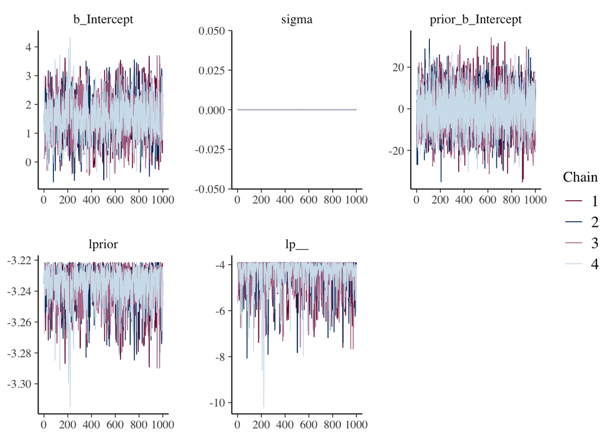

```r
color_scheme_set("mix-blue-pink")
posterior_model_chf <- as.array(model_chf)
mcmc_trace(posterior_model_chf)
```

### b. Trace rank plot

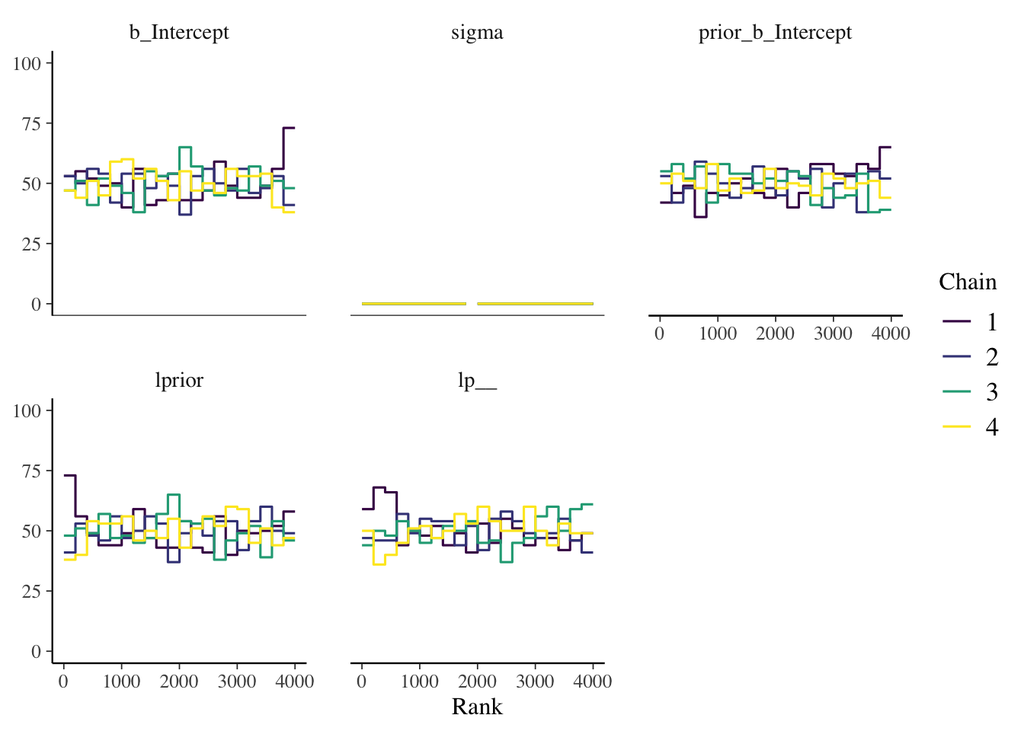

```r
color_scheme_set("viridis")
mcmc_rank_overlay(posterior_model_chf) +
  ylim(0, 100)
```

## 5. get summary of model

```r
summary(model_chf)
```

```
##  Family: gaussian
##   Links: mu = identity
## Formula: estimate | se(error) ~ 0 + Intercept
##    Data: df_chf (Number of observations: 1)
##   Draws: 4 chains, each with iter = 2000; warmup = 1000; thin = 1;
##          total post-warmup draws = 4000
##
## Regression Coefficients:
##           Estimate Est.Error l-95% CI u-95% CI Rhat Bulk_ESS Tail_ESS
## Intercept     1.58      0.77     0.04     3.08 1.00      990     1065
##
## Further Distributional Parameters:
##       Estimate Est.Error l-95% CI u-95% CI Rhat Bulk_ESS Tail_ESS
## sigma     0.00      0.00     0.00     0.00   NA       NA       NA
##
## Draws were sampled using sampling(NUTS). For each parameter, Bulk_ESS
## and Tail_ESS are effective sample size measures, and Rhat is the potential
## scale reduction factor on split chains (at convergence, Rhat = 1).
```

## 6. Get location (median estimate) and scale (SD)

```r
draws <- as.matrix(model_chf)
location_chf <- mean(draws[,1]) # draws for type
scale_chf <- sd(draws[,1])
location_chf
```

```
## [1] 1.57583
```

```r
scale_chf
```

```
## [1] 0.7705384
```

## 7. Compare prior and posterior

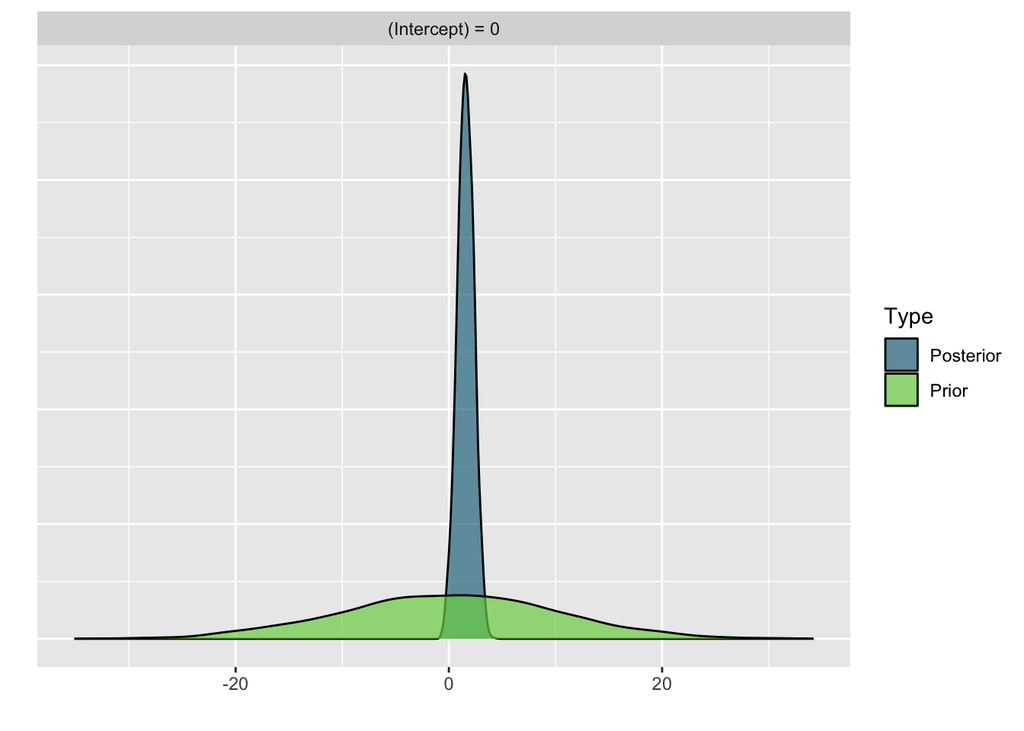

```r
plot(hypothesis(model_chf, "Intercept = 0"))
```

## 8. Decision…

**Set an informative prior…**

student_t(df = 3, location = 1.57583, scale = 0.7705384)

### a. Prior for beta of pv_max

```r
prior_beta_chf <- student_t(df = 3, location = location_chf, scale = scale_chf, autoscale = TRUE)
```

### b. Suggested scales assuming strong, moderate and weak priors.

The strong prior is based on the combined estimate from the literature, whilst moderate and weak priors are then scaled up from the strong prior. These latter priors ensure that the data are not overwhelmed by the prior, but still allow for some regularisation to improve model convergence and reduce overfitting. Therefore, strong prior should be 1x the combine scale, then increase this by 2x for moderate and 4x for weak.

```r
strong_scale <- scale_chf
moderate_scale <- strong_scale * 2
weak_scale <- strong_scale * 4

prior_scale_chf <- matrix(c(strong_scale,
                        moderate_scale,
                        weak_scale)
)
colnames(prior_scale_chf) <- "suggested scale"
rownames(prior_scale_chf) <- c("strong", "moderate", "weak")
prior_scale_chf
```

```
##          suggested scale
## strong         0.7705384
## moderate       1.5410768
## weak           3.0821537
```

### c. Priors bin

```r
priors_bin_chf <- list(
  weak = student_t(df = 3, location = location_chf, scale = weak_scale, autoscale = TRUE),
  moderate = student_t(df = 3, location = location_chf, scale = moderate_scale, autoscale = TRUE),
  strong = student_t(df = 3, location = location_chf, scale = strong_scale, autoscale = TRUE)
)
```

## 9. Plot comparison of study distribution vs. posterior

### a. Generate posterior for plotting

```r
# 1. Extract the Posterior and Prior draws
draws <- model_chf %>%
  spread_draws(b_Intercept) %>%
  dplyr::rename(Posterior = b_Intercept) %>%
  pivot_longer(cols = Posterior, names_to = "Source", values_to = "Value")

# 2. Define the Likelihood parameters (from Locatelli study)
locatelli_med <- median_exp_l_chf
locatelli_se   <- scale_l_chf

# 3. Define the Likelihood parameters (from Chetboul study)
chetboul_med <- median_exp_c_chf
chetboul_se   <- scale_c_chf

# 4. Define the Likelihood parameters (from Bonvin study)
bonvin_med <- median_exp_b_chf
bonvin_se   <- scale_b_chf
```

### b. Create the density plot

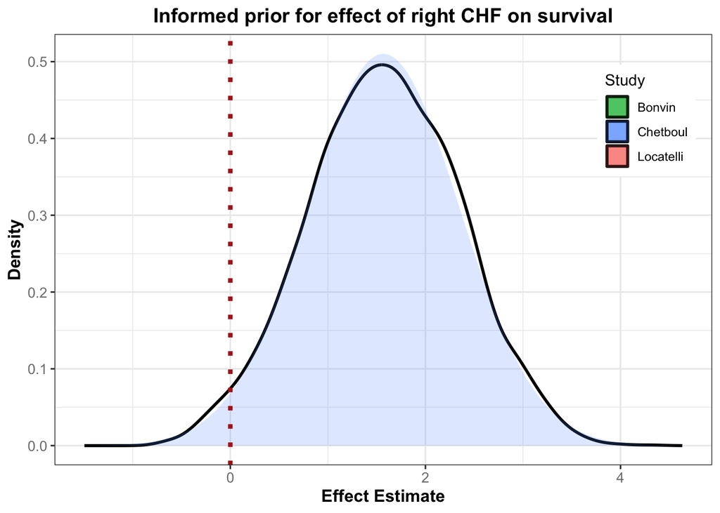

```r
# Create the Plot
ggplot() +
  # LAYER 1: Posterior (from your HMC draws)
  geom_density(
    data = draws,
    aes(x = Value),
    alpha = 0.7,
    color = "black",
    linewidth = 1
  ) +

  # LAYER 2: Distribution from Locatelli (Generated mathematically to match the others)
  # We use stat_function with 'geom = "area"' to create a shaded shape
  stat_function(
    data = data.frame(Value = c(locatelli_med - 3.92 * locatelli_se, locatelli_med + 3.92 * locatelli_se)),
    aes(x = Value, fill = "Locatelli"),
    fun = dnorm,
    args = list(mean = locatelli_med , sd = locatelli_se),
    geom = "area",
    alpha = 0.2,
    inherit.aes = FALSE
  ) +

   # LAYER 3: Distribution from Chetboul (Generated mathematically to match the others)
  # We use stat_function with 'geom = "area"' to create a shaded shape
  stat_function(
    data = data.frame(Value = c(chetboul_med - 3.92 * chetboul_se, chetboul_med + 3.92 * chetboul_se)),
    aes(x = Value, fill = "Chetboul"),
    fun = dnorm,
    args = list(mean = chetboul_med, sd = chetboul_se),
    geom = "area",
    alpha = 0.2,
    inherit.aes = FALSE
  ) +

    # LAYER 4: Distribution from Bonvin (Generated mathematically to match the others)
  # We use stat_function with 'geom = "area"' to create a shaded shape
  stat_function(
    data = data.frame(Value = c(bonvin_med - 3.96 * bonvin_se, bonvin_med + 3.96 * bonvin_se)),
    aes(x = Value, fill = "Bonvin"),
    fun = dnorm,
    args = list(mean = bonvin_med, sd = bonvin_se),
    geom = "area",
    alpha = 0.2,
    inherit.aes = FALSE
  ) +

   # Styling the Colors
  scale_fill_manual(
    values = c(
      "Locatelli" = "#F8766D",
      "Chetboul" = "#619CFF",
      "Bonvin" = "#00BA38"
    )
  ) +
  labs(
    title = "Informed prior for effect of right CHF on survival",
    x = "Effect Estimate",
    y = "Density",
    fill = "Component"
  ) +
  theme_bw() +
  theme(legend.position = c(0.9, 0.8)) +
  labs(fill = "Study") +

           theme(axis.title.y = element_text(size=12, face="bold"),
               axis.title.x = element_text(size=12, face="bold"),
               plot.title = element_text(hjust = 0.5, size=14, face="bold"),
               plot.subtitle = element_text(size = 12, hjust = 0.5, face = "italic"),
               axis.text.x = element_text(color = "grey50", size = 10),
               axis.text.y = element_text(color = "grey50",size = 10)) +
  geom_vline(xintercept = 0, linetype="dotted",
                color = "firebrick", linewidth = 1.5)
```

# XI. ARRHYTHMIAS

Coded as… • 0 (no) • 1 (yes)

## Decision…

No prior information on the effect of arrhythmias. Therefore, set a non-informative weekly regularising prior… ~ student_t(df = 3, location = 0, scale = 2.5)

# XII. ATENOLOL

Coded as… • 0 (no) • 1 (yes)

## 1. Previous studies for atenolol

### a. Locatelli

Did not assess the effect of atenolol

```r
median_exp_l_atenolol <- NA
lower_exp_l_atenolol <- NA
upper_exp_l_atenolol <- NA
range_l_atenolol <- upper_exp_l_atenolol - lower_exp_l_atenolol
scale_l_atenolol <- range_l_atenolol / 4
prior_exp_l_atenolol <- matrix(c(median_exp_l_atenolol,
                    range_l_atenolol,
                    scale_l_atenolol)
)
colnames(prior_exp_l_atenolol) <- "locatelli"
rownames(prior_exp_l_atenolol) <- c("location", "range", "scale")
prior_exp_l_atenolol
```

```
##          locatelli
## location        NA
## range           NA
## scale           NA
```

### c. Chetboul 2018

Did not assess the effect of atenolol

```r
median_exp_c_atenolol <- NA
lower_exp_c_atenolol<-NA
upper_exp_c_atenolol <- NA
range_c_atenolol <- upper_exp_c_atenolol - lower_exp_c_atenolol
scale_c_atenolol <- range_c_atenolol / 4
prior_exp_c_atenolol <- matrix(c(median_exp_c_atenolol,
                    range_c_atenolol,
                    scale_c_atenolol)
)
colnames(prior_exp_c_atenolol) <- "chetboul"
rownames(prior_exp_c_atenolol) <- c("location", "range", "scale")
prior_exp_c_atenolol
```

```
##          chetboul
## location       NA
## range          NA
## scale          NA
```

### c.Bonvin (Utrecht Thesis, 2019)

• Atenolol therapy: paradoxically associated with shorter survival in PBV dogs 6.349 (1.198-33.641)

```r
median_exp_b_atenolol <- log(6.349)
lower_exp_b_atenolol<- log(1.198)
upper_exp_b_atenolol <- log(33.641)
range_b_atenolol <- upper_exp_b_atenolol - lower_exp_b_atenolol
scale_b_atenolol <- range_b_atenolol / 4
prior_exp_b_atenolol <- matrix(c(median_exp_b_atenolol,
                    range_b_atenolol,
                    scale_b_atenolol)
)
colnames(prior_exp_b_atenolol) <- "bonvin"
rownames(prior_exp_b_atenolol) <- c("location", "range", "scale")
prior_exp_b_atenolol
```

```
##            bonvin
## location 1.848297
## range    3.335092
## scale    0.833773
```

## 2. Set very weak neutral regularising prior

very small datasets (1-3 values) , so prior could impact on the posterior significantly. Therefore, set scale to 10, make prior virtually flat but not uniform.

```r
prior_atenolol <- set_prior("normal(0, 10)", class = "b", coef = "Intercept")
```

## 3. Create a dataframe for the likelihood based on the Chetboul study

```r
df_atenolol <- data.frame(
  estimate = c(median_exp_l_atenolol, median_exp_c_atenolol, median_exp_b_atenolol), # Observed scales for all studies
  error = c(scale_l_atenolol, scale_c_atenolol, scale_b_atenolol)      # Observed SD (Standard Error) for all studies
)
```

## 4. Run model

```r
set.seed(999)
model_atenolol <- brm(estimate | se(error) ~ 0 + Intercept,
                   family = gaussian(),
                   data = df_atenolol,
                   prior = prior_atenolol,
                   control=list(adapt_delta=0.98),
                   iter = 2000, warmup = 1000,
                   save_pars = save_pars(all =TRUE),
                   sample_prior = TRUE)
```

```
## Trying to compile a simple C file
```

[output not shown]

## View MCMC trace plots

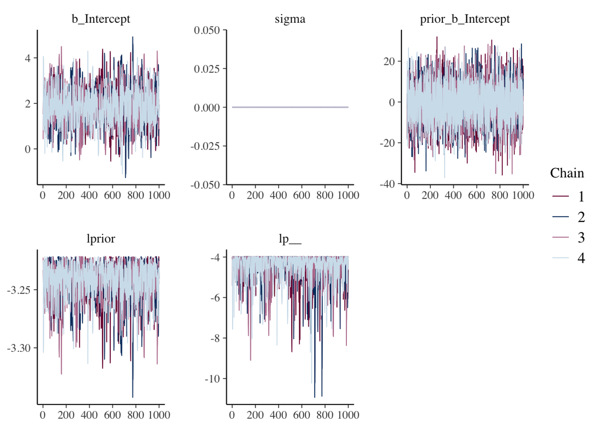

```r
color_scheme_set("mix-blue-pink")
posterior_model_atenolol <- as.array(model_atenolol)
mcmc_trace(posterior_model_atenolol)
```

### b. Trace rank plot

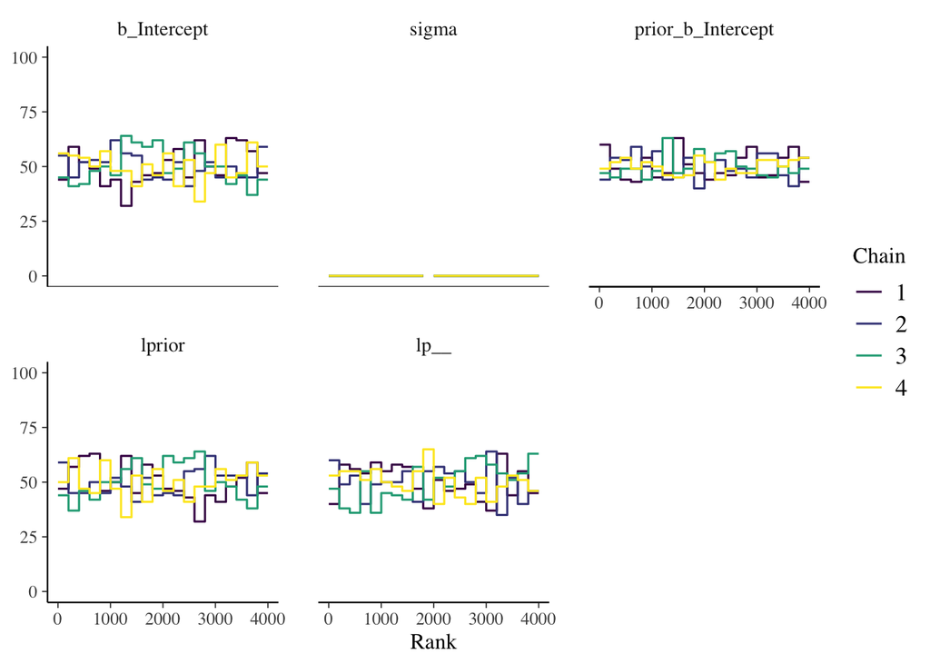

```r
color_scheme_set("viridis")
mcmc_rank_overlay(posterior_model_atenolol) +
  ylim(0, 100)
```

## 5. get summary of model

```r
summary(model_atenolol)
```

```
##  Family: gaussian
##   Links: mu = identity
## Formula: estimate | se(error) ~ 0 + Intercept
##    Data: df_atenolol (Number of observations: 1)
##   Draws: 4 chains, each with iter = 2000; warmup = 1000; thin = 1;
##          total post-warmup draws = 4000
##
## Regression Coefficients:
##           Estimate Est.Error l-95% CI u-95% CI Rhat Bulk_ESS Tail_ESS
## Intercept     1.87      0.84     0.23     3.56 1.00     1244     1121
##
## Further Distributional Parameters:
##       Estimate Est.Error l-95% CI u-95% CI Rhat Bulk_ESS Tail_ESS
## sigma     0.00      0.00     0.00     0.00   NA       NA       NA
##
## Draws were sampled using sampling(NUTS). For each parameter, Bulk_ESS
## and Tail_ESS are effective sample size measures, and Rhat is the potential
## scale reduction factor on split chains (at convergence, Rhat = 1).
```

## 6. Get location (median estimate) and scale (SD)

```r
draws <- as.matrix(model_atenolol)
location_atenolol <- mean(draws[,1]) # draws for type
scale_atenolol <- sd(draws[,1])
location_atenolol
```

```
## [1] 1.866284
```

```r
scale_atenolol
```

```
## [1] 0.8443848
```

## 7. Compare prior and posterior

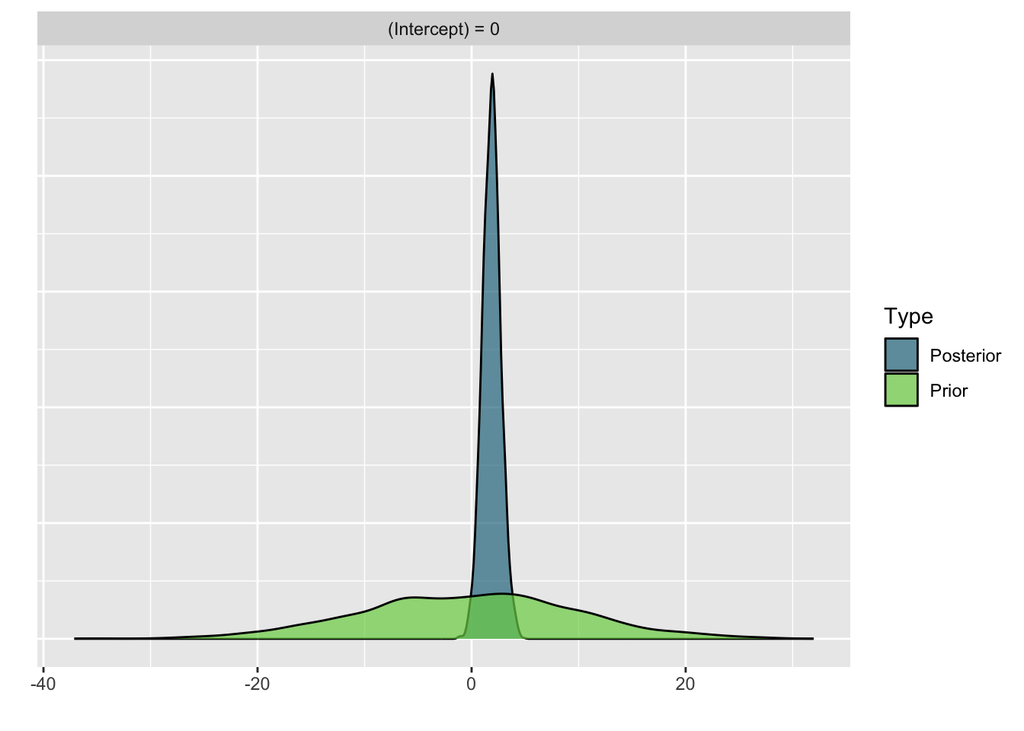

```r
plot(hypothesis(model_atenolol, "Intercept = 0"))
```

## 8. Decision…

**Set an informative prior…**

student_t(df = 3, location = 1.866284, scale = 0.8443848)

### a. Prior for beta of pv_max

```r
prior_beta_atenolol <- student_t(df = 3, location = location_atenolol, scale = scale_atenolol, autoscale = TRUE)
```

### b. Suggested scales assuming strong, moderate and weak priors.

The strong prior is based on the combined estimate from the literature, whilst moderate and weak priors are then scaled up from the strong prior. These latter priors ensure that the data are not overwhelmed by the prior, but still allow for some regularisation to improve model convergence and reduce overfitting. Therefore, strong prior should be 1x the combine scale, then increase this by 2x for moderate and 4x for weak.

```r
strong_scale <- scale_atenolol
moderate_scale <- strong_scale * 2
weak_scale <- strong_scale * 4

prior_scale_atenolol <- matrix(c(strong_scale,
                        moderate_scale,
                        weak_scale)
)
colnames(prior_scale_atenolol) <- "suggested scale"
rownames(prior_scale_atenolol) <- c("strong", "moderate", "weak")
prior_scale_atenolol
```

```
##          suggested scale
## strong         0.8443848
## moderate       1.6887697
## weak           3.3775394
```

### c. Priors bin

```r
priors_bin_atenolol <- list(
  weak = student_t(df = 3, location = location_atenolol, scale = weak_scale, autoscale = TRUE),
  moderate = student_t(df = 3, location = location_atenolol, scale = moderate_scale, autoscale = TRUE),
  strong = student_t(df = 3, location = location_atenolol, scale = strong_scale, autoscale = TRUE)
)
```

## 9. Plot comparison of study distribution vs. posterior

### a. Generate posterior for plotting

```r
# 1. Extract the Posterior and Prior draws
draws <- model_atenolol %>%
  spread_draws(b_Intercept) %>%
  dplyr::rename(Posterior = b_Intercept) %>%
  pivot_longer(cols = Posterior, names_to = "Source", values_to = "Value")

# 2. Define the Likelihood parameters (from Locatelli study)
locatelli_med <- median_exp_l_atenolol
locatelli_se   <- scale_l_atenolol

# 3. Define the Likelihood parameters (from Chetboul study)
chetboul_med <- median_exp_c_atenolol
chetboul_se   <- scale_c_atenolol

# 4. Define the Likelihood parameters (from Bonvin study)
bonvin_med <- median_exp_b_atenolol
bonvin_se   <- scale_b_atenolol
```

### b. Create the density plot

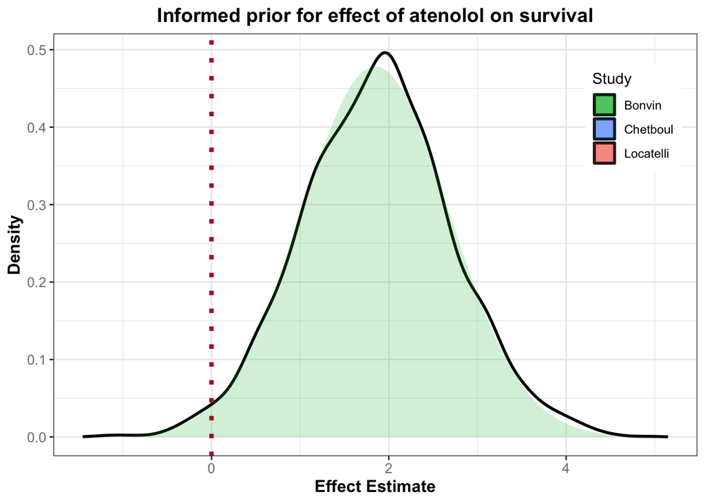

```r
# Create the Plot
ggplot() +
  # LAYER 1: Posterior (from your HMC draws)
  geom_density(
    data = draws,
    aes(x = Value),
    alpha = 0.7,
    color = "black",
    linewidth = 1
  ) +

  # LAYER 2: Distribution from Locatelli (Generated mathematically to match the others)
  # We use stat_function with 'geom = "area"' to create a shaded shape
  stat_function(
    data = data.frame(Value = c(locatelli_med - 3.92 * locatelli_se, locatelli_med + 3.92 * locatelli_se)),
    aes(x = Value, fill = "Locatelli"),
    fun = dnorm,
    args = list(mean = locatelli_med , sd = locatelli_se),
    geom = "area",
    alpha = 0.2,
    inherit.aes = FALSE
  ) +

   # LAYER 3: Distribution from Chetboul (Generated mathematically to match the others)
  # We use stat_function with 'geom = "area"' to create a shaded shape
  stat_function(
    data = data.frame(Value = c(chetboul_med - 3.92 * chetboul_se, chetboul_med + 3.92 * chetboul_se)),
    aes(x = Value, fill = "Chetboul"),
    fun = dnorm,
    args = list(mean = chetboul_med, sd = chetboul_se),
    geom = "area",
    alpha = 0.2,
    inherit.aes = FALSE
  ) +

    # LAYER 4: Distribution from Bonvin (Generated mathematically to match the others)
  # We use stat_function with 'geom = "area"' to create a shaded shape
  stat_function(
    data = data.frame(Value = c(bonvin_med - 3.96 * bonvin_se, bonvin_med + 3.96 * bonvin_se)),
    aes(x = Value, fill = "Bonvin"),
    fun = dnorm,
    args = list(mean = bonvin_med, sd = bonvin_se),
    geom = "area",
    alpha = 0.2,
    inherit.aes = FALSE
  ) +

   # Styling the Colors
  scale_fill_manual(
    values = c(
      "Locatelli" = "#F8766D",
      "Chetboul" = "#619CFF",
      "Bonvin" = "#00BA38"
    )
  ) +
  labs(
    title = "Informed prior for effect of atenolol on survival",
    x = "Effect Estimate",
    y = "Density",
    fill = "Component"
  ) +
  theme_bw() +
  theme(legend.position = c(0.9, 0.8)) +
  labs(fill = "Study") +

           theme(axis.title.y = element_text(size=12, face="bold"),
               axis.title.x = element_text(size=12, face="bold"),
               plot.title = element_text(hjust = 0.5, size=14, face="bold"),
               plot.subtitle = element_text(size = 12, hjust = 0.5, face = "italic"),
               axis.text.x = element_text(color = "grey50", size = 10),
               axis.text.y = element_text(color = "grey50",size = 10)) +
  geom_vline(xintercept = 0, linetype="dotted",
                color = "firebrick", linewidth = 1.5)
```

# XIII. PROCEDURE TYPE

Coded as… • Balloon • Stent

## Decision…

No prior information on the effect of procedure type. Therefore, set a non-informative weekly regularising prior… ~ student_t(df = 3, location = 0, scale = 2.5)

# XIV. COMPLICATIONS

Coded as… • 0 (no) • 1 (yes)

## Decision…

No prior information on the effect of complications. Therefore, set a non-informative weekly regularising prior… ~ student_t(df = 3, location = 0, scale = 2.5)

# XV. CONCURRENT CONGENITAL

Coded as… • 0 (no) • 1 (yes)

Scansen, Advances in the Treatment of Pulmonary Valve Stenosis • Coronary artery anomalies (e.g., aberrant coronary that courses near annulus) — increases procedural risk (risk of coronary compression/occlusion during interventions) and therefore influences treatment selection and outcomes for interventional procedures.

Borgeat et al., J Vet Cardiol 2021 (Transvalvular Stent Angioplasty) • Concurrent congenital defects (e.g., tetralogy of Fallot, ASD, VSD, tricuspid dysplasia) → complicate prognosis.

## Decision…

No prior information on the effect of concurrent congenital diseases. Therefore, set a non-informative weekly regularising prior… ~ student_t(df = 3, location = 0, scale = 2.5)

# XVI. TRUCUSPID REGURGITATION (need variable)

Coded as… • 0 (no) • 1 (yes)

Chetboul et al., Specific features and survival of French bulldogs • Severe tricuspid regurgitation (color Doppler area ≥ 50% RA) — univariate HR = 7.6 (p = 0.001); after adjustment for age & DP: HR = 5.1, p = 0.02. (Remained an independent predictor of CD).

Locatelli et al., JSAP 2013 • High Doppler gradient → increased risk of death in untreated dogs (HR ~1.02 per mmHg).

Bonvin (Utrecht Thesis, 2019) • Tricuspid regurgitation: strong negative prognostic factor (HR ~3.5).

Average of the Chetboul and Bonvin studies…

```r
(7.6 + 3.5) / 2
```

```
## [1] 5.55
```

## Coefficient for HR of 5.55

```r
log(5.55)
```

```
## [1] 1.713798
```

## Decision…

NOT ASSESSED AS DO NOT HAVE COMPLETE DATA FROM ENOUGH ANIMALS

# XVII. CLINICAL SIGNS (need variable)

Coded as… • 0 (no) • 1 (yes)

## 1. Previous studies for clinical signs

### a. Using Locatelli

Locatelli et al., JSAP 2013 • Clinical signs at presentation (presence vs absent) — HR = 3.44, p < 0.001. (Symptomatic dogs worse prognosis). HR 3.44 (1.706 to 6.944)

```r
median_exp_l_cs <- log(3.44)
lower_exp_l_cs <- log(1.706)
upper_exp_l_cs <- log(6.944)
range_l_cs <- upper_exp_l_cs - lower_exp_l_cs
scale_l_cs <- range_l_cs / 4
prior_exp_l_cs <- matrix(c(median_exp_l_cs,
                    range_l_cs,
                    scale_l_cs)
)
colnames(prior_exp_l_cs) <- "locatelli"
rownames(prior_exp_l_cs) <- c("location", "range", "scale")
prior_exp_l_cs
```

```
##          locatelli
## location 1.2354715
## range    1.4037265
## scale    0.3509316
```

### b. Using Chetboul

Chetboul et al., Specific features and survival of French bulldogs • Clinical signs at presentation (presence vs absent) — HR = 3.7, p = 0.03. (Symptomatic dogs worse prognosis). 3.7 (95% confidence interval 1.1 to 12.1)

```r
median_exp_c_cs <- log(3.7)
lower_exp_c_cs<- log(1.1)
upper_exp_c_cs <- log(12.1)
range_c_cs <- upper_exp_c_cs - lower_exp_c_cs
scale_c_cs <- range_c_cs / 4
prior_exp_c_cs <- matrix(c(median_exp_c_cs,
                    range_c_cs,
                    scale_c_cs)
)
colnames(prior_exp_c_cs) <- "chetboul"
rownames(prior_exp_c_cs) <- c("location", "range", "scale")
prior_exp_c_cs
```

```
##           chetboul
## location 1.3083328
## range    2.3978953
## scale    0.5994738
```

### c. Using Bonvin

Bonvin et al • Clinical signs aassociated with a poorer outcome HR 2.546 (1.053 to 6.156)

```r
median_exp_b_cs <- log(2.546)
lower_exp_b_cs <- log(1.053)
upper_exp_b_cs <- log(6.156)
range_b_cs <- upper_exp_b_cs - lower_exp_b_cs
scale_b_cs <- range_b_cs / 4
prior_exp_b_cs <- matrix(c(median_exp_b_cs,
                    range_b_cs,
                    scale_b_cs)
)
colnames(prior_exp_b_cs) <- "bonvin"
rownames(prior_exp_b_cs) <- c("location", "range", "scale")
prior_exp_b_cs
```

```
##             bonvin
## location 0.9345235
## range    1.7657840
## scale    0.4414460
```

## 2. Set very weak neutral regularising prior

very small datasets (1-3 values) , so prior could impact on the posterior significantly. Therefore, set scale to 10, make prior virtually flat but not uniform.

```r
prior_cs <- set_prior("normal(0, 10)", class = "b", coef = "Intercept")
```

## 3. Create a dataframe for the likelihood based on the Chetboul study

```r
df_cs <- data.frame(
  estimate = c(median_exp_l_cs, median_exp_c_cs, median_exp_b_cs), # Observed scales for all studies
  error = c(scale_l_cs, scale_c_cs, scale_b_cs)      # Observed SD (Standard Error) for all studies
)
```

## 4. Run model

```r
set.seed(999)
model_cs <- brm(estimate | se(error) ~ 0 + Intercept,
                   family = gaussian(),
                   data = df_cs,
                   prior = prior_cs,
                   control=list(adapt_delta=0.98),
                   iter = 2000, warmup = 1000,
                   save_pars = save_pars(all =TRUE),
                   sample_prior = TRUE)
```

```
## Trying to compile a simple C file
```

[output not shown]

## View MCMC trace plots

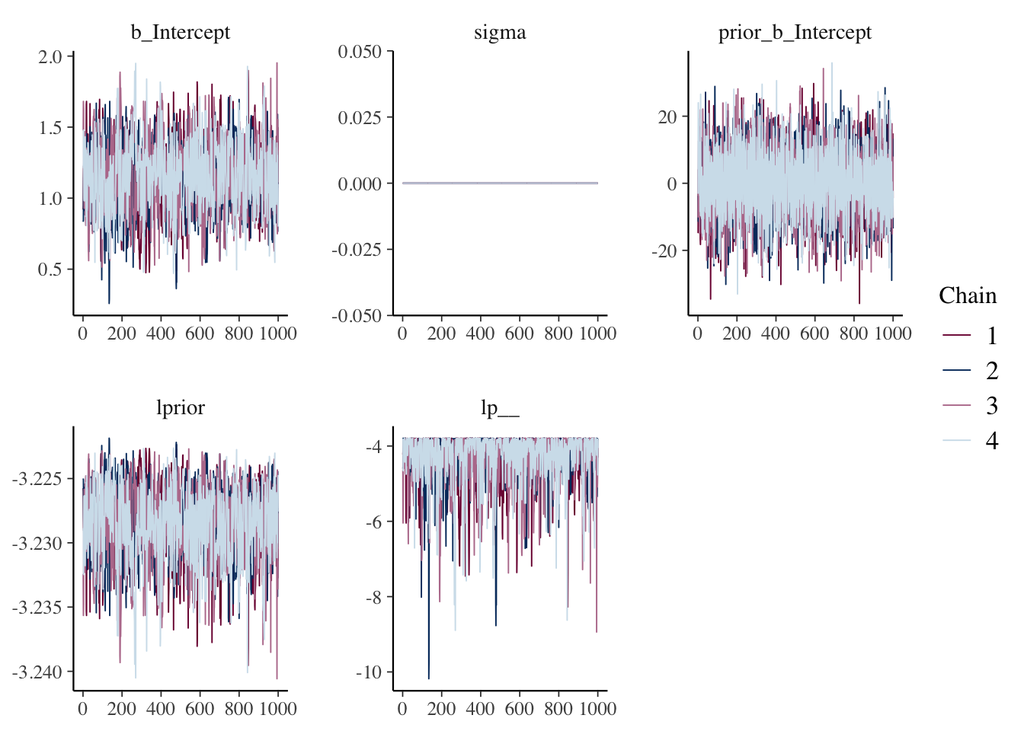

```r
color_scheme_set("mix-blue-pink")
posterior_model_cs <- as.array(model_cs)
mcmc_trace(posterior_model_cs)
```

### b. Trace rank plot

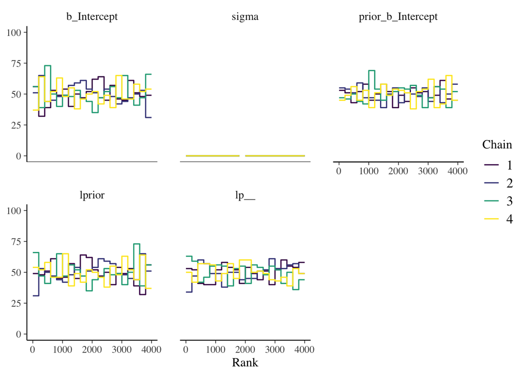

```r
color_scheme_set("viridis")
mcmc_rank_overlay(posterior_model_cs) +
  ylim(0, 100)
```

## 5. get summary of model

```r
summary(model_cs)
```

```
##  Family: gaussian
##   Links: mu = identity
## Formula: estimate | se(error) ~ 0 + Intercept
##    Data: df_cs (Number of observations: 3)
##   Draws: 4 chains, each with iter = 2000; warmup = 1000; thin = 1;
##          total post-warmup draws = 4000
##
## Regression Coefficients:
##           Estimate Est.Error l-95% CI u-95% CI Rhat Bulk_ESS Tail_ESS
## Intercept     1.15      0.25     0.66     1.63 1.00     1240     1062
##
## Further Distributional Parameters:
##       Estimate Est.Error l-95% CI u-95% CI Rhat Bulk_ESS Tail_ESS
## sigma     0.00      0.00     0.00     0.00   NA       NA       NA
##
## Draws were sampled using sampling(NUTS). For each parameter, Bulk_ESS
## and Tail_ESS are effective sample size measures, and Rhat is the potential
## scale reduction factor on split chains (at convergence, Rhat = 1).
```

## 6. Get location (median estimate) and scale (SD)

```r
draws <- as.matrix(model_cs)
location_cs <- mean(draws[,1]) # draws for type
scale_cs <- sd(draws[,1])
location_cs
```

```
## [1] 1.150538
```

```r
scale_cs
```

```
## [1] 0.2454828
```

## 7. Compare prior and posterior

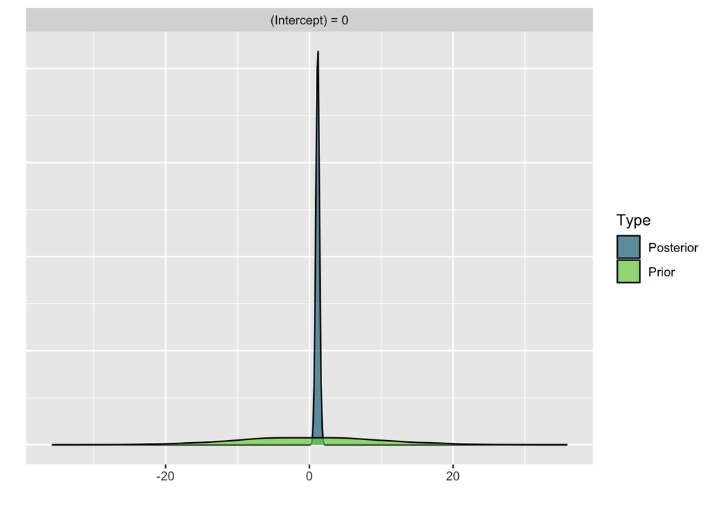

```r
plot(hypothesis(model_cs, "Intercept = 0"))
```

## 8. Decision…

**Set an informative prior…**

student_t(df = 3, location = 1.150538, scale = 0.2454828)

### a. Prior for beta of clinical_signs

```r
prior_beta_cs <- student_t(df = 3, location = location_cs, scale = scale_cs, autoscale = TRUE)
```

### b. Suggested scales assuming strong, moderate and weak priors.

```r
strong_scale <- scale_cs
moderate_scale <- strong_scale * 2
weak_scale <- strong_scale * 4

prior_scale_cs <- matrix(c(strong_scale,
                        moderate_scale,
                        weak_scale)
)
colnames(prior_scale_cs) <- "suggested scale"
rownames(prior_scale_cs) <- c("strong", "moderate", "weak")
prior_scale_cs
```

```
##          suggested scale
## strong         0.2454828
## moderate       0.4909656
## weak           0.9819312
```

### c. Priors bin

```r
priors_bin_cs <- list(
  weak = student_t(df = 3, location = location_cs, scale = weak_scale, autoscale = TRUE),
  moderate = student_t(df = 3, location = location_cs, scale = moderate_scale, autoscale = TRUE),
  strong = student_t(df = 3, location = location_cs, scale = strong_scale, autoscale = TRUE)
)
```

## 9. Plot comparison of study distribution vs. posterior

### a. Generate posterior for plotting

```r
# 1. Extract the Posterior and Prior draws
draws <- model_cs %>%
  spread_draws(b_Intercept) %>%
  dplyr::rename(Posterior = b_Intercept) %>%
  pivot_longer(cols = Posterior, names_to = "Source", values_to = "Value")

# 2. Define the Likelihood parameters (from Locatelli study)
locatelli_med <- median_exp_l_cs
locatelli_se   <- scale_l_cs

# 3. Define the Likelihood parameters (from Chetboul study)
chetboul_med <- median_exp_c_cs
chetboul_se   <- scale_c_cs

# 4. Define the Likelihood parameters (from Bonvin study)
bonvin_med <- median_exp_b_cs
bonvin_se   <- scale_b_cs
```

### b. Create the density plot

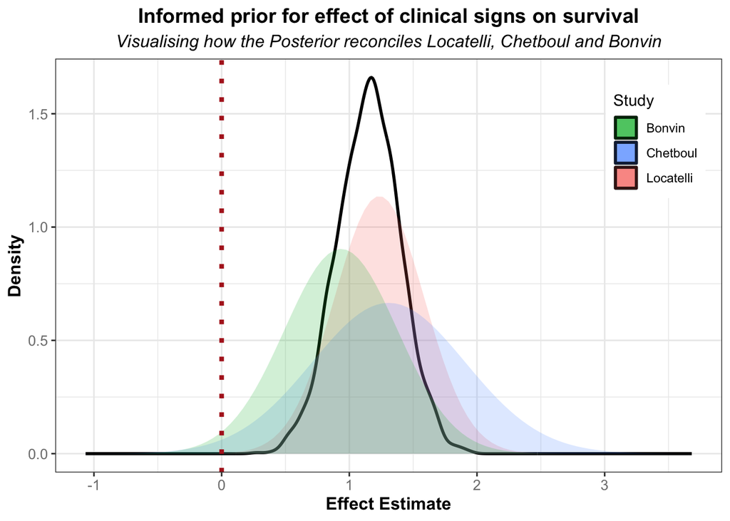

```r
# Create the Plot
ggplot() +
  # LAYER 1: Posterior (from your HMC draws)
  geom_density(
    data = draws,
    aes(x = Value),
    alpha = 0.7,
    color = "black",
    linewidth = 1
  ) +


  # LAYER 2: Distribution from Locatelli (Generated mathematically to match the others)
  # We use stat_function with 'geom = "area"' to create a shaded shape
  stat_function(
    data = data.frame(Value = c(locatelli_med - 3.96*locatelli_se, locatelli_med + 3.96*locatelli_se)),
    aes(x = Value, fill = "Locatelli"),
    fun = dnorm,
    args = list(mean = locatelli_med , sd = locatelli_se),
    geom = "area",
    alpha = 0.2,
    inherit.aes = FALSE
  ) +

   # LAYER 3: Distribution from Chetboul (Generated mathematically to match the others)
  # We use stat_function with 'geom = "area"' to create a shaded shape
  stat_function(
    data = data.frame(Value = c(chetboul_med - 3.96 * chetboul_se, chetboul_med + 3.96 * chetboul_se)),
    aes(x = Value, fill = "Chetboul"),
    fun = dnorm,
    args = list(mean = chetboul_med, sd = chetboul_se),
    geom = "area",
    alpha = 0.2,
    inherit.aes = FALSE
  ) +

    # LAYER 4: Distribution from Bonvin (Generated mathematically to match the others)
  # We use stat_function with 'geom = "area"' to create a shaded shape
  stat_function(
    data = data.frame(Value = c(bonvin_med - 3.96 * bonvin_se, bonvin_med + 3.96 * bonvin_se)),
    aes(x = Value, fill = "Bonvin"),
    fun = dnorm,
    args = list(mean = bonvin_med, sd = bonvin_se),
    geom = "area",
    alpha = 0.2,
    inherit.aes = FALSE
  ) +


  # Styling the Colors
  scale_fill_manual(
    values = c(
      "Locatelli" = "#F8766D",
      "Chetboul" = "#619CFF",
      "Bonvin" = "#00BA38"
    )
  ) +
  labs(
    title = "Informed prior for effect of clinical signs on survival",
    subtitle = "Visualising how the Posterior reconciles Locatelli, Chetboul and Bonvin",
    x = "Effect Estimate",
    y = "Density",
    fill = "Component"
  ) +
  theme_bw() +
  theme(legend.position = c(0.9, 0.8)) +
  labs(fill = "Study") +

           theme(axis.title.y = element_text(size=12, face="bold"),
               axis.title.x = element_text(size=12, face="bold"),
               plot.title = element_text(hjust = 0.5, size=14, face="bold"),
               plot.subtitle = element_text(size = 12, hjust = 0.5, face = "italic"),
               axis.text.x = element_text(color = "grey50", size = 10),
               axis.text.y = element_text(color = "grey50",size = 10)) +
  geom_vline(xintercept = 0, linetype="dotted",
                color = "firebrick", linewidth = 1.5)
```

# XVIII. BALLOON TYPE

Coded as… • high_pressure • low_pressure

Lytle et al. 2026 Journal of Veterinary Cardiology (2026) 63, 81—90 https://doi.org/10.1016/j.jvc.2025.11.002 Examined changes after HP vs LP balloon dilation Similar changes after treatment, with no difference in systolic pressure between groups (P = 0.9014)

## Decision…

No prior information on the effect of balloon type on survival Therefore, set a non-informative weekly regularising prior… ~ student_t(df = 3, location = 0, scale = 2.5)